# AI-powered Bayesian inference: linear regression part

DSC536 project, O’Hagan & Ročková (2025), arXiv:2502.19231

26 November 2026

This document contains the code and a short explanation of every step of the regression part of the project. It runs offline from the files saved in the repository. The only step that needs the internet (asking the LLM for predictions) is shown but not re-run; its outputs are saved in `data/llm/`.

**Question.** How is weekly AI use (`ai_hours_per_week`) related to students’ critical-thinking score (0-100) and CGPA (0-4), and does an LLM-based prior, built as in O’Hagan & Ročková (2025), improve the inference when only a few labelled students are available?

# 1 Data

```r
data_raw <- read.csv(file.path(ROOT, "data", "campus_ai_pulse_2026.csv"), stringsAsFactors = TRUE)
dim(data_raw)
```

```
## [1] 1200   24
```

```r
# columns removed before modelling (same as the first draft, bapr2.R): the ID and variables that
# are other outcomes or derived scores rather than predictors
DROP_COLS <- c("uses_ai", "paid_ai_subscription", "prompt_skill_level", "time_saved_pct",
               "ai_dependency_score", "ai_dependency_level", "integrity_concern_level",
               "flagged_by_ai_detector", "would_recommend_ai")
data <- data_raw[, setdiff(names(data_raw), DROP_COLS)]
kable(data.frame(column = names(data_raw),
                 type = sapply(data_raw, function(v) class(v)[1]),
                 used = ifelse(names(data_raw) %in% names(data) & names(data_raw) != "student_id",
                               "yes", "no"), row.names = NULL))
```

| column | type | used |
| --- | --- | --- |
| student_id | factor | no |
| age | integer | yes |
| gender | factor | yes |
| country | factor | yes |
| university_type | factor | yes |
| program | factor | yes |
| year_of_study | integer | yes |
| uni_ai_policy | factor | yes |
| uses_ai | factor | no |
| primary_ai_tool | factor | yes |
| primary_use_case | factor | yes |
| ai_hours_per_week | numeric | yes |
| paid_ai_subscription | factor | no |
| prompt_skill_level | integer | no |
| ai_assignment_share_pct | integer | yes |
| study_hours_per_week | numeric | yes |
| cgpa | numeric | yes |
| critical_thinking_score | integer | yes |
| time_saved_pct | integer | no |
| ai_dependency_score | integer | no |
| ai_dependency_level | factor | no |
| integrity_concern_level | integer | no |
| flagged_by_ai_detector | factor | no |
| would_recommend_ai | factor | no |

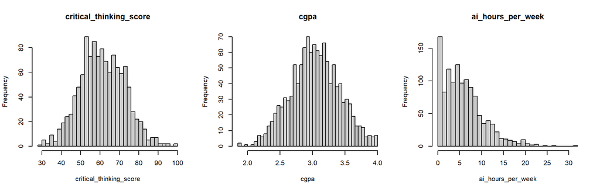

```r
par(mfrow = c(1, 3))
for (v in c("critical_thinking_score", "cgpa", "ai_hours_per_week"))
  hist(data[[v]], breaks = 40, main = v, xlab = v, col = "grey80")
```

## 1.1 Data checks

`data_check.R` checks types, missing values, duplicates, impossible values, distributions, rare levels, leakage, collinearity and the OLS fit. The summary table:

```r
Sys.setenv(CHECK_OUT_DIR = file.path(OUT, "data_check"))
invisible(capture.output(source(file.path(ROOT, "regression", "data_check.R"), local = new.env())))
chk <- read.csv(file.path(OUT, "data_check", "summary_checks.csv"))
kable(chk[!grepl("^LLM|Split|AI rows|NA in LLM", chk$check), c("check", "result", "problem")])
```

| check | result | problem |
| --- | --- | --- |
| Columns dropped by bapr2.R | student_id, uses_ai, paid_ai_subscription, prompt_skill_level, time_saved_pct, ai_dependency_score, ai_dependency_level, integrity_concern_level, flagged_by_ai_detector, would_recommend_ai | CHECK |
| Leakage (single-column R2 > 0.5 for an outcome) | none | no |
| cor(score, cgpa) | 0.624 | no |
| Dimensions (raw / after drop) | 1200 x 24 / 1200 x 14 | no |
| Numeric columns wrongly read as factors | none | no |
| Missing / empty / sentinel codes | none | no |
| Duplicated rows / rows dup. ignoring col 1 / dup. values in col 1 | 0 / 0 / 0 | no |
| Impossible values: cgpa outside 0-4 / score outside 0-100 / ai_hours <0 or >112 | 0 / 0 / 0 | no |
| Age range | 18-24 | no |
| Ceiling / floor (>5% at min or max) | ai_hours_per_week | YES |
| Suspiciously perfect normal/uniform shape (KS p > 0.5) | cgpa | CHECK (synthetic?) |
| Rare factor levels (<10 rows) in modelling data | none | no |
| Max VIF (numeric predictors, given all others) | ai_assignment_share_pct = 4.76 | no |
| OLS score_all: R2, beta_ai [95% CI] | R2=0.070, beta=-0.479 [-0.773, -0.185], partial R2(ai)=0.0088 | no |
| OLS score_only: R2, beta_ai [95% CI] | R2=0.015, beta=-0.301 [-0.441, -0.16], partial R2(ai)=0.0145 | YES (weak signal) |
| OLS cgpa_all: R2, beta_ai [95% CI] | R2=0.094, beta=0.00797 [-0.00157, 0.0175], partial R2(ai)=0.0023 | YES (weak signal) |
| OLS cgpa_only: R2, beta_ai [95% CI] | R2=0.009, beta=0.00787 [0.00324, 0.0125], partial R2(ai)=0.0092 | YES (weak signal) |
| Rows available vs 300 known + 900 AI | 1200 rows; 1200 used; 0 unused | no |

Main points: the data are clean (no missing values, duplicates or impossible values, no leakage), but `cgpa` is almost perfectly normal and capped at 4, which suggests the dataset is **simulated**, and the signal is weak. `primary_use_case = "No AI use"` is the same 148 rows as `primary_ai_tool = "No AI tool"`, so it is dropped from the “all covariates” models.

## 1.2 The target: OLS on all 1200 students

```r
fit_s <- lm(critical_thinking_score ~ ai_hours_per_week, data = data)
fit_g <- lm(cgpa ~ ai_hours_per_week, data = data)
kable(rbind(score = c(coef(fit_s)[2], confint(fit_s)[2, ], R2 = summary(fit_s)$r.squared),
            cgpa  = c(coef(fit_g)[2], confint(fit_g)[2, ], R2 = summary(fit_g)$r.squared)),
      digits = 4, col.names = c("beta(ai_hours)", "2.5%", "97.5%", "R2"))
```

|  | beta(ai_hours) | 2.5% | 97.5% | R2 |
| --- | --- | --- | --- | --- |
| score | -0.3005 | -0.4407 | -0.1603 | 0.0145 |
| cgpa | 0.0079 | 0.0032 | 0.0125 | 0.0092 |

One more hour of AI use per week goes with about 0.3 points lower critical-thinking score, and a very small positive change in CGPA. Both effects explain only 1-2% of the variance.

# 2 LLM predictions (the AI prior)

`llm_prior_labels.R` splits the students with a fixed seed into **300 labelled** (“known”) rows and **900 AI rows** whose outcomes are hidden. For every AI row it asks an LLM (`gpt-oss-20b` on Groq) for a probability distribution over 8 CGPA bins and 10 score bins, given the student’s features only. This needs an API key, so it is not re-run here:

```r
# needs GROQ_API_KEY in ~/.Renviron; resumes from the cache if interrupted
source("regression/llm_prior_labels.R")
```

One saved answer (students are matched back by their id, not by position):

```r
split <- readRDS(file.path(LLM, "llm_split_v2.rds"))
resp  <- readRDS(file.path(LLM, "llm_responses_v2.rds"))
cat(substr(resp[[1]]$text, 1, 400), "...\n")
```

```
## {"students":[{"id":"S0510","cgpa":[0.01,0.02,0.03,0.04,0.05,0.06,0.15,0.64],"score":[0.02,0.03,0.04,0.05,0.07,0.12,0.20,0.25,0.15,0.07]},{"id":"S0727","cgpa":[0.02,0.03,0.04,0.05,0.06,0.08,0.10,0.62],"score":[0.02,0.03,0.04,0.05,0.07,0.10,0.15,0.20,0.25,0.10]},{"id":"S0485","cgpa":[0.01,0.02,0.03…
```

```r
c(known = length(split$known_ids), ai = length(split$ai_ids))
```

```
## known    ai
##   300   900
```

## 2.1 How good are the LLM predictions?

The true outcomes of the AI rows are used **only** here, to evaluate the LLM.

```r
probs <- readRDS(file.path(LLM, "llm_probs_v2.rds"))
truth <- data[match(probs$student_id, data$student_id), ]
llm_quality <- function(pr, tr) data.frame(
  outcome   = c("critical_thinking_score", "cgpa"),
  mean_llm  = c(mean(pr$exp_score), mean(pr$exp_cgpa)),
  mean_true = c(mean(tr$critical_thinking_score), mean(tr$cgpa)),
  cor       = c(cor(pr$exp_score, tr$critical_thinking_score), cor(pr$exp_cgpa, tr$cgpa)),
  slope_llm  = c(coef(lm(pr$exp_score ~ tr$ai_hours_per_week))[2], coef(lm(pr$exp_cgpa ~ tr$ai_hours_per_week))[2]),
  slope_true = c(coef(lm(tr$critical_thinking_score ~ tr$ai_hours_per_week))[2], coef(lm(tr$cgpa ~ tr$ai_hours_per_week))[2]))
kable(llm_quality(probs, truth), digits = 3)
```

| outcome | mean_llm | mean_true | cor | slope_llm | slope_true |
| --- | --- | --- | --- | --- | --- |
| critical_thinking_score | 71.526 | 61.789 | -0.029 | 0.332 | -0.295 |
| cgpa | 3.190 | 3.048 | -0.010 | 0.022 | 0.008 |

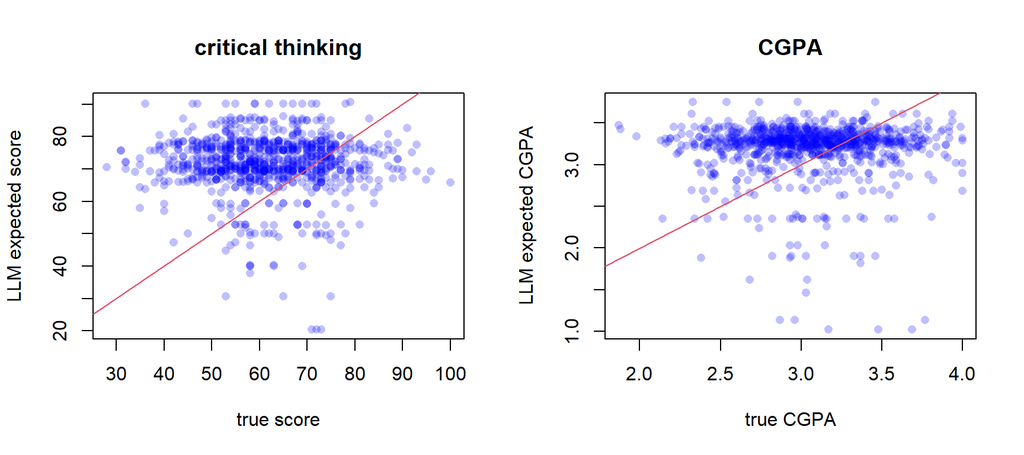

```r
par(mfrow = c(1, 2))
plot(truth$critical_thinking_score, probs$exp_score, pch = 16, col = "#0000ff40",
     xlab = "true score", ylab = "LLM expected score", main = "critical thinking"); abline(0, 1, col = 2)
plot(truth$cgpa, probs$exp_cgpa, pch = 16, col = "#0000ff40",
     xlab = "true CGPA", ylab = "LLM expected CGPA", main = "CGPA"); abline(0, 1, col = 2)
```

The LLM is too optimistic and its predictions are essentially uncorrelated with the truth. Most importantly, its implied effect of AI hours on critical thinking has the **opposite sign** to the data.

# 3 Method

**Setting.** We have $n$ labelled students $(Y_i, X_i)$ and $m$ unlabelled students $X^*_j$ for which the LLM gives a predictive distribution $f_{AI}(Y \mid X^*_j)$. The parameter of interest is the regression coefficient of `ai_hours_per_week`, defined as the minimiser of the squared-error loss.

**AI prior (paper, Section 3.2).** A Dirichlet process prior $F \sim DP(\alpha, F_{AI})$ on the data-generating distribution, whose base measure $F_{AI}$ is “features of the unlabelled students, labels drawn from the LLM”. The concentration $\alpha$ is the prior strength: the prior is worth $\alpha$ data points. $\alpha = 0$ uses only the real data; $\alpha = m$ treats every AI row like a real one (what the first draft did).

**Posterior bootstrap (paper, Algorithm 1).** For $t = 1, \dots, B$: draw fake rows from $F_{AI}$, draw weights $(w_{1:n}, w^*_{1:m}) \sim \text{Dir}(1, \dots, 1, \alpha/m, \dots, \alpha/m)$, and compute the weighted least-squares fit. The $B$ fitted coefficients are draws from the posterior.

A minimal version for `score ~ ai_hours` with the 300 known students:

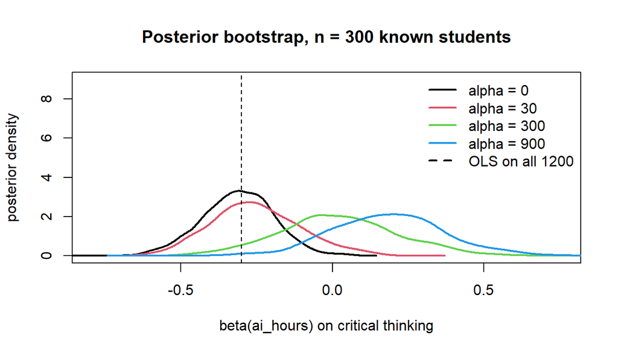

```r
set.seed(30175)
X  <- cbind(1, data$ai_hours_per_week); y <- data$critical_thinking_score
kn <- match(split$known_ids, data$student_id)            # 300 labelled rows
ai <- match(split$ai_ids, data$student_id)               # 900 AI rows
P  <- as.matrix(probs[paste0("p_score_", 1:10)])         # LLM distribution per AI row
lo <- seq(0, 90, 10)

posterior_bootstrap <- function(alpha, B = 1000, m = length(ai)) {
  replicate(B, {
    w  <- rgamma(length(kn), 1)                          # Dirichlet(1,...,1) for real rows
    s  <- sample(length(ai), m, replace = TRUE)          # X* from the unlabelled students
    ys <- lo[apply(P[s, ], 1, function(p) sample(10, 1, prob = p))] + runif(m, 0, 10)  # Y* ~ LLM
    ws <- if (alpha > 0) rgamma(m, alpha / m) else rep(0, m)                           # Dir(alpha/m)
    Xa <- rbind(X[kn, ], X[ai[s], ]); ya <- c(y[kn], ys); wa <- c(w, ws)
    solve(crossprod(Xa, Xa * wa), crossprod(Xa, ya * wa))[2]
  })
}
alphas <- c(0, 30, 300, 900)
draws  <- lapply(alphas, posterior_bootstrap)
plot(NA, xlim = range(unlist(draws)), ylim = c(0, 9), xlab = "beta(ai_hours) on critical thinking",
     ylab = "posterior density", main = "Posterior bootstrap, n = 300 known students")
for (k in seq_along(alphas)) lines(density(draws[[k]]), col = k, lwd = 2)
abline(v = coef(fit_s)[2], lty = 2)
legend("topright", c(paste("alpha =", alphas), "OLS on all 1200"), col = c(seq_along(alphas), 1),
       lty = c(rep(1, length(alphas)), 2), lwd = 2, bty = "n")
```

As $\alpha$ grows, the posterior moves from the real-data estimate towards the LLM’s (wrong) positive effect. The whole question is therefore **how to choose $\alpha$**.

**Choosing $\alpha$ (paper, Section 4.1).**

- *Out-of-sample:* 10-fold cross-validated log predictive density on the known rows (“CV”).
- *Coverage calibration (Section 4.1.1):* bootstrap the known rows, treat the known-data estimate as the truth of the bootstrap world, and take the **largest** $\alpha$ whose 90% intervals still cover it at least 90% of the time (“cal”). Inside this loop the posterior-bootstrap interval is replaced by its normal approximation from the paper’s Theorem 1, which is much faster.

**Comparison prior.** We also fit the “power” (catalytic) AI prior of the paper’s Section 2.1, which raises the AI-row likelihood to the power $\alpha/m$. With a normal linear model this is conjugate (closed form), and we average the AI log-likelihood over the full LLM distribution instead of using one sampled label.

**Benchmark (PPI).** Prediction-powered inference (Angelopoulos et al. 2023), the method the paper compares with, estimates the coefficient as $\hat\theta^{Y}_{L} + \lambda(\hat\theta^{f}_{U} - \hat\theta^{f}_{L})$: OLS on the real labels of the labelled students, plus the difference between OLS on the AI predictions of the unlabelled and of the labelled students. With $\lambda = 1$ (PPI) the AI’s bias, measured on the labelled students, is removed; PPI++ tunes $\lambda \in [0, 1]$ to minimise the variance. It needs one prediction per student (we use the mean of the LLM’s distribution), including the labelled students, which is why the v3 run also labels them.

The full implementation is `regression_power_prior.R` (see the Appendix). It repeats everything for both outcomes, with `ai_hours` only and with all covariates, with 300 and 100 known students, on the saved split and on 100 random splits (600 AI rows each; the truth is the OLS fit on all rows not used as known rows).

```r
Sys.setenv(LLM_TAG = "v2")
source(file.path(ROOT, "regression", "regression_power_prior.R"), local = new.env())
```

# 4 Results with the first LLM run (v2)

This section uses the v2 labels (`gpt-oss-20b`, 15 students per request, 900 AI students). Section 5 repeats the analysis with the paper-style v3 labels, which are the main results of the report.

```r
single  <- read.csv(file.path(OUT, "single_split_summary.csv"))
rep_sum <- read.csv(file.path(OUT, "replicates_summary.csv"))
rep_alpha <- read.csv(file.path(OUT, "replicates_by_alpha.csv"))
getv <- function(model, n, setting, col)
  rep_sum[rep_sum$model == model & rep_sum$n_known == n & rep_sum$setting == setting, col]
```

## 4.1 One split

Posterior mean and 90% interval of the AI-hours coefficient (`a=` gives the chosen $\alpha$):

```r
kable(single[, c("model", "n_known", "truth", "known_only", "pooled_w1", "power_cv", "pb_cal")])
```

| model | n_known | truth | known_only | pooled_w1 | power_cv | pb_cal |
| --- | --- | --- | --- | --- | --- | --- |
| score_only | 300 | -0.29500 | -0.318 [-0.541, -0.0943] | 0.182 [-0.0264, 0.391] | -0.318 [-0.541, -0.0943] | -0.258 [-0.479, 0.0085] a=30 |
| score_only | 100 | -0.30500 | -0.265 [-0.607, 0.0765] | 0.29 [0.0524, 0.527] | -0.258 [-0.606, 0.0908] a=1 | -0.0989 [-0.506, 0.317] a=30 |
| score_all | 300 | -0.38100 | -0.687 [-1.14, -0.23] | -0.0926 [-0.53, 0.345] | -0.659 [-1.14, -0.175] a=10 | -0.479 [-1.04, 0.142] a=100 |
| score_all | 100 | -0.42200 | -0.731 [-1.38, -0.0864] | 0.00898 [-0.492, 0.51] | -0.704 [-1.54, 0.128] a=10 | -0.339 [-1.24, 0.447] a=100 |
| cgpa_only | 300 | 0.00827 | 0.00651 [-0.00105, 0.0141] | 0.0183 [0.0102, 0.0264] | 0.00651 [-0.00105, 0.0141] | 0.0104 [0.000415, 0.0215] a=100 |
| cgpa_only | 100 | 0.00769 | 0.00897 [-0.00413, 0.0221] | 0.0209 [0.0114, 0.0303] | 0.00897 [-0.00413, 0.0221] | 0.0201 [0.00647, 0.0343] a=300 |
| cgpa_all | 300 | 0.00978 | 0.0027 [-0.0124, 0.0177] | 0.00363 [-0.0133, 0.0205] | 0.00284 [-0.0134, 0.0191] a=10 | 0.0036 [-0.0187, 0.0268] a=1000 |
| cgpa_all | 100 | 0.01050 | -0.0164 [-0.0408, 0.00794] | 0.0021 [-0.0177, 0.0219] | -0.0133 [-0.0441, 0.0175] a=10 | -0.00061 [-0.0302, 0.032] a=300 |

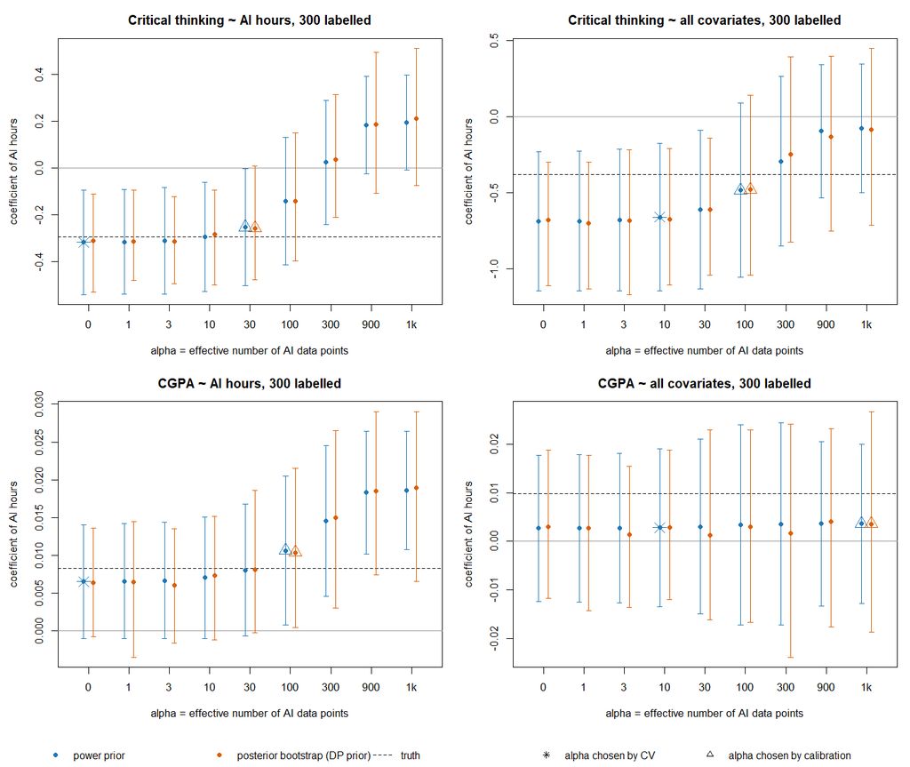

## 4.2 100 random splits

```r
settings <- c(known_only = "real data only (alpha = 0)", pooled_w1 = "1:1 pooling (alpha = m)",
              power_cv = "power prior, alpha by CV", power_cal = "power prior, alpha by calibration",
              pb_cal = "posterior bootstrap, alpha by calibration",
              ppi = "PPI (lambda = 1)", ppi_pp = "PPI++ (tuned lambda)")      # PPI only in the v3 results
tab <- rep_sum[rep_sum$setting %in% names(settings),
               c("model", "n_known", "setting", "mean_alpha", "bias", "rmse", "coverage", "sign_ok")]
tab$setting <- settings[tab$setting]
kable(tab, digits = 3, row.names = FALSE,
      col.names = c("model", "n known", "method", "mean alpha", "bias", "RMSE", "90% coverage", "correct sign"))
```

| model | n known | method | mean alpha | bias | RMSE | 90% coverage | correct sign |
| --- | --- | --- | --- | --- | --- | --- | --- |
| score_only | 300 | real data only (alpha = 0) | 0.00 | 0.012 | 0.146 | 0.91 | 0.99 |
| score_only | 300 | 1:1 pooling (alpha = m) | 600.00 | 0.432 | 0.442 | 0.01 | 0.02 |
| score_only | 300 | power prior, alpha by CV | 1.25 | 0.015 | 0.146 | 0.91 | 0.99 |
| score_only | 300 | power prior, alpha by calibration | 38.70 | 0.071 | 0.176 | 0.84 | 0.96 |
| score_only | 300 | posterior bootstrap, alpha by calibration | 53.30 | 0.095 | 0.191 | 0.86 | 0.95 |
| score_only | 100 | real data only (alpha = 0) | 0.00 | 0.052 | 0.293 | 0.85 | 0.82 |
| score_only | 100 | 1:1 pooling (alpha = m) | 600.00 | 0.557 | 0.563 | 0.00 | 0.00 |
| score_only | 100 | power prior, alpha by CV | 1.26 | 0.060 | 0.292 | 0.86 | 0.80 |
| score_only | 100 | power prior, alpha by calibration | 172.14 | 0.209 | 0.376 | 0.72 | 0.60 |
| score_only | 100 | posterior bootstrap, alpha by calibration | 179.60 | 0.231 | 0.377 | 0.73 | 0.58 |
| score_all | 300 | real data only (alpha = 0) | 0.00 | -0.076 | 0.337 | 0.88 | 0.99 |
| score_all | 300 | 1:1 pooling (alpha = m) | 600.00 | 0.349 | 0.394 | 0.78 | 0.73 |
| score_all | 300 | power prior, alpha by CV | 11.00 | -0.053 | 0.322 | 0.89 | 0.99 |
| score_all | 300 | power prior, alpha by calibration | 392.00 | 0.141 | 0.361 | 0.80 | 0.89 |
| score_all | 300 | posterior bootstrap, alpha by calibration | 404.40 | 0.160 | 0.356 | 0.93 | 0.88 |
| score_all | 100 | real data only (alpha = 0) | 0.00 | -0.049 | 0.632 | 0.84 | 0.78 |
| score_all | 100 | 1:1 pooling (alpha = m) | 600.00 | 0.499 | 0.519 | 0.82 | 0.33 |
| score_all | 100 | power prior, alpha by CV | 14.85 | 0.043 | 0.511 | 0.94 | 0.81 |
| score_all | 100 | power prior, alpha by calibration | 434.70 | 0.196 | 0.576 | 0.64 | 0.60 |
| score_all | 100 | posterior bootstrap, alpha by calibration | 432.20 | 0.273 | 0.507 | 0.91 | 0.59 |
| cgpa_only | 300 | real data only (alpha = 0) | 0.00 | 0.000 | 0.005 | 0.87 | 0.97 |
| cgpa_only | 300 | 1:1 pooling (alpha = m) | 600.00 | 0.009 | 0.010 | 0.48 | 1.00 |
| cgpa_only | 300 | power prior, alpha by CV | 0.98 | 0.000 | 0.005 | 0.88 | 0.98 |
| cgpa_only | 300 | power prior, alpha by calibration | 222.70 | 0.004 | 0.007 | 0.80 | 1.00 |
| cgpa_only | 300 | posterior bootstrap, alpha by calibration | 242.10 | 0.004 | 0.007 | 0.90 | 1.00 |
| cgpa_only | 100 | real data only (alpha = 0) | 0.00 | 0.001 | 0.009 | 0.84 | 0.86 |
| cgpa_only | 100 | 1:1 pooling (alpha = m) | 600.00 | 0.012 | 0.013 | 0.35 | 1.00 |
| cgpa_only | 100 | power prior, alpha by CV | 0.93 | 0.001 | 0.009 | 0.87 | 0.86 |
| cgpa_only | 100 | power prior, alpha by calibration | 396.30 | 0.007 | 0.011 | 0.60 | 0.97 |
| cgpa_only | 100 | posterior bootstrap, alpha by calibration | 415.90 | 0.008 | 0.011 | 0.88 | 0.97 |
| cgpa_all | 300 | real data only (alpha = 0) | 0.00 | -0.002 | 0.011 | 0.81 | 0.76 |
| cgpa_all | 300 | 1:1 pooling (alpha = m) | 600.00 | -0.004 | 0.007 | 1.00 | 0.91 |
| cgpa_all | 300 | power prior, alpha by CV | 9.86 | -0.002 | 0.011 | 0.85 | 0.76 |
| cgpa_all | 300 | power prior, alpha by calibration | 969.00 | -0.004 | 0.007 | 1.00 | 0.94 |
| cgpa_all | 300 | posterior bootstrap, alpha by calibration | 958.00 | -0.004 | 0.007 | 1.00 | 0.90 |
| cgpa_all | 100 | real data only (alpha = 0) | 0.00 | 0.001 | 0.021 | 0.81 | 0.65 |
| cgpa_all | 100 | 1:1 pooling (alpha = m) | 600.00 | -0.004 | 0.006 | 1.00 | 0.90 |
| cgpa_all | 100 | power prior, alpha by CV | 9.98 | 0.000 | 0.017 | 0.94 | 0.70 |
| cgpa_all | 100 | power prior, alpha by calibration | 708.30 | -0.003 | 0.009 | 0.99 | 0.87 |
| cgpa_all | 100 | posterior bootstrap, alpha by calibration | 685.30 | -0.003 | 0.008 | 1.00 | 0.88 |

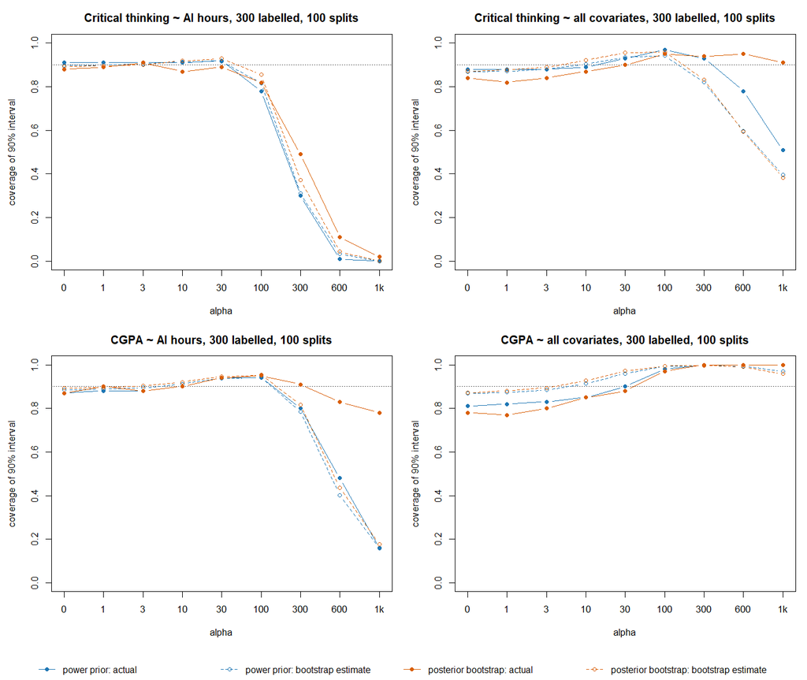

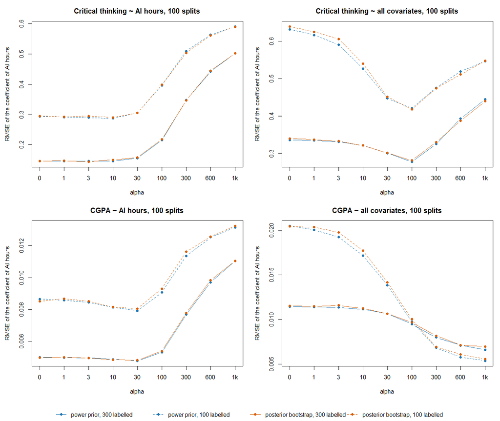

## 4.3 What the results show

- **1:1 pooling fails.** For critical thinking with 300 known students, the 90% interval covers the truth in 1% of splits and the sign is correct in 2% (real data only: 91% and 99%).
- **Choosing $\alpha$ by CV protects the analysis.** CV gives the AI rows almost no weight (mean $\alpha$ = 1.2 for `score_only`), so the results are as good as with real data only, and slightly better in the models with many covariates.
- **Coverage calibration is too permissive with a biased LLM and few labels.** Its bootstrap estimate of coverage follows the actual coverage closely on average (figure above), but choosing the *largest* acceptable $\alpha$ often overshoots: with 100 known students the coverage drops to 72%.
- **Posterior bootstrap vs power prior.** Both give almost the same estimates; the posterior bootstrap gives wider, more honest intervals when the AI weight is large.
- **Where the prior helps.** For CGPA with all covariates the LLM’s (near-zero) adjusted effect is close to the truth, and the AI rows stabilise the many coefficients (RMSE 0.011 → 0.0071).

# 5 Second LLM run in the paper’s style (v3): main results

`llm_prior_labels_v3.R` repeats the elicitation in the paper’s style: one student per call, a detailed prompt that explains every feature, temperature 0.7, medium reasoning effort, and a larger model (`gpt-oss-120b`, served by Groq). All 900 AI students were labelled (611 through Groq’s free tier, the remaining 289 through OpenRouter routed to Groq, i.e. the same model and provider), and so were the 300 labelled students, whose predictions are needed for PPI:

```r
Sys.setenv(LLM_PROVIDER = "openrouter")                     # paid key OPENROUTER_API_KEY, pinned to Groq
source("regression/llm_prior_labels_v3.R")                  # 900 AI students
Sys.setenv(LLM_TARGET = "known"); source("regression/llm_prior_labels_v3.R")   # 300 labelled students
Sys.setenv(LLM_TARGET = "ai", LLM_TAG = "v3"); source("regression/regression_power_prior.R")
```

The 100 random splits use 600 of the 900 AI students each, exactly the same splits as the v2 analysis in Section 4, so the two runs can be compared split by split. Results are in `regression/output_v3/`.

```r
f_v3   <- file.path(LLM, paste0("llm_probs_", params$llm_tag_extra, ".rds"))
out_v3 <- file.path(ROOT, "regression", paste0("output_", params$llm_tag_extra))
if (!file.exists(f_v3)) {
  cat("*The", params$llm_tag_extra, "run is not finished yet; this section fills in automatically",
      "once `", basename(f_v3), "` exists.*\n")
} else {
  p3 <- readRDS(f_v3); t3 <- data[match(p3$student_id, data$student_id), ]
  p2 <- probs[match(p3$student_id, probs$student_id), ]      # v2 on the SAME students
  cat("LLM predictions vs truth: both runs evaluated on the same", nrow(p3), "AI students.\n\n")
  q  <- rbind(cbind(run = "v2 (gpt-oss-20b, 15 per call)", llm_quality(p2, t3)),
              cbind(run = paste(params$llm_tag_extra, "(paper style, gpt-oss-120b)"), llm_quality(p3, t3)))
  print(kable(q, digits = 3, row.names = FALSE))
  if (file.exists(file.path(out_v3, "replicates_summary.csv"))) {
    r3 <- read.csv(file.path(out_v3, "replicates_summary.csv"))
    r3 <- r3[r3$setting %in% names(settings) & r3$model %in% c("score_only", "cgpa_only"),
             c("model", "n_known", "setting", "mean_alpha", "mean_lambda", "rmse", "coverage", "width", "sign_ok")]
    r3$setting <- settings[r3$setting]
    cat("\n\n100 random splits with the", params$llm_tag_extra, "labels:\n\n")
    print(kable(r3, digits = 3, row.names = FALSE))
  } else {
    cat("\n\n*Run `Sys.setenv(LLM_TAG = \"", params$llm_tag_extra,
        "\"); source(\"regression/regression_power_prior.R\")` to add the 100-split results.*\n", sep = "")
  }
}
```

LLM predictions vs truth: both runs evaluated on the same 900 AI students.

| run | outcome | mean_llm | mean_true | cor | slope_llm | slope_true |
| --- | --- | --- | --- | --- | --- | --- |
| v2 (gpt-oss-20b, 15 per call) | critical_thinking_score | 71.526 | 61.789 | -0.029 | 0.332 | -0.295 |
| v2 (gpt-oss-20b, 15 per call) | cgpa | 3.190 | 3.048 | -0.010 | 0.022 | 0.008 |
| v3 (paper style, gpt-oss-120b) | critical_thinking_score | 62.392 | 61.789 | 0.095 | -0.418 | -0.295 |
| v3 (paper style, gpt-oss-120b) | cgpa | 2.885 | 3.048 | 0.047 | -0.006 | 0.008 |

100 random splits with the v3 labels:

| model | n_known | setting | mean_alpha | mean_lambda | rmse | coverage | width | sign_ok |
| --- | --- | --- | --- | --- | --- | --- | --- | --- |
| score_only | 300 | real data only (alpha = 0) | 0.00 | NA | 0.146 | 0.91 | 0.465 | 0.99 |
| score_only | 300 | 1:1 pooling (alpha = m) | 600.00 | NA | 0.108 | 0.93 | 0.369 | 1.00 |
| score_only | 300 | power prior, alpha by CV | 6.06 | NA | 0.143 | 0.92 | 0.466 | 0.99 |
| score_only | 300 | power prior, alpha by calibration | 723.60 | NA | 0.132 | 0.80 | 0.361 | 1.00 |
| score_only | 300 | posterior bootstrap, alpha by calibration | 744.60 | NA | 0.129 | 0.96 | 0.506 | 1.00 |
| score_only | 300 | PPI (lambda = 1) | 0.00 | 1.000 | 0.181 | 0.85 | 0.551 | 0.97 |
| score_only | 300 | PPI++ (tuned lambda) | 0.00 | 0.034 | 0.147 | 0.90 | 0.464 | 0.99 |
| score_only | 100 | real data only (alpha = 0) | 0.00 | NA | 0.293 | 0.85 | 0.823 | 0.82 |
| score_only | 100 | 1:1 pooling (alpha = m) | 600.00 | NA | 0.116 | 0.98 | 0.446 | 1.00 |
| score_only | 100 | power prior, alpha by CV | 6.42 | NA | 0.274 | 0.88 | 0.826 | 0.85 |
| score_only | 100 | power prior, alpha by calibration | 524.13 | NA | 0.209 | 0.88 | 0.565 | 0.92 |
| score_only | 100 | posterior bootstrap, alpha by calibration | 541.20 | NA | 0.202 | 0.94 | 0.687 | 0.91 |
| score_only | 100 | PPI (lambda = 1) | 0.00 | 1.000 | 0.347 | 0.82 | 0.923 | 0.80 |
| score_only | 100 | PPI++ (tuned lambda) | 0.00 | 0.135 | 0.296 | 0.81 | 0.808 | 0.81 |
| cgpa_only | 300 | real data only (alpha = 0) | 0.00 | NA | 0.005 | 0.87 | 0.015 | 0.97 |
| cgpa_only | 300 | 1:1 pooling (alpha = m) | 600.00 | NA | 0.010 | 0.23 | 0.015 | 0.14 |
| cgpa_only | 300 | power prior, alpha by CV | 1.61 | NA | 0.005 | 0.88 | 0.016 | 0.97 |
| cgpa_only | 300 | power prior, alpha by calibration | 171.30 | NA | 0.007 | 0.77 | 0.017 | 0.79 |
| cgpa_only | 300 | posterior bootstrap, alpha by calibration | 175.50 | NA | 0.007 | 0.83 | 0.018 | 0.79 |
| cgpa_only | 300 | PPI (lambda = 1) | 0.00 | 1.000 | 0.006 | 0.89 | 0.020 | 0.89 |
| cgpa_only | 300 | PPI++ (tuned lambda) | 0.00 | 0.060 | 0.005 | 0.88 | 0.016 | 0.95 |
| cgpa_only | 100 | real data only (alpha = 0) | 0.00 | NA | 0.009 | 0.84 | 0.027 | 0.86 |
| cgpa_only | 100 | 1:1 pooling (alpha = m) | 600.00 | NA | 0.012 | 0.09 | 0.019 | 0.00 |
| cgpa_only | 100 | power prior, alpha by CV | 1.64 | NA | 0.008 | 0.86 | 0.028 | 0.86 |
| cgpa_only | 100 | power prior, alpha by calibration | 300.20 | NA | 0.010 | 0.66 | 0.026 | 0.52 |
| cgpa_only | 100 | posterior bootstrap, alpha by calibration | 299.90 | NA | 0.010 | 0.78 | 0.029 | 0.53 |
| cgpa_only | 100 | PPI (lambda = 1) | 0.00 | 1.000 | 0.010 | 0.88 | 0.032 | 0.81 |
| cgpa_only | 100 | PPI++ (tuned lambda) | 0.00 | 0.168 | 0.009 | 0.85 | 0.028 | 0.85 |

**What the v3 results show** (100 random splits, AI hours only):

- **The AI prior helps when the LLM’s belief points the right way.** For critical thinking with 100 labelled students, 1:1 pooling reduces the RMSE from 0.293 to 0.116 and the interval width from 0.82 to 0.45, with coverage 0.98 and the correct sign in 100% of splits.
- **It fails when the LLM’s belief points the wrong way.** For CGPA, 1:1 pooling covers the truth in 23% (300 labelled) and 9% (100 labelled) of splits.
- **CV is safe but cautious** (mean alpha 6.4 for critical thinking, RMSE 0.274 with 100 labelled), because it judges the AI by its predictions for individual students, which are poor.
- **Coverage calibration captures the benefit but not the risk**: RMSE 0.202 for critical thinking, but coverage 0.78 for CGPA (posterior bootstrap, 100 labelled).
- **The posterior bootstrap keeps more honest intervals than the power prior** under heavy AI weight: coverage 0.58 vs 0.23 for CGPA with 1:1 pooling (300 labelled).
- **PPI is safe but gains nothing here.** It corrects the LLM’s bias, so it stays valid for CGPA (coverage 0.88 with 100 labelled, vs 0.09 for 1:1 pooling), but it is less precise than the real data for critical thinking (RMSE 0.347 vs 0.293), because the LLM cannot predict individual students. PPI++ gives the predictions little weight (mean lambda 0.13) and reproduces the real-data results.

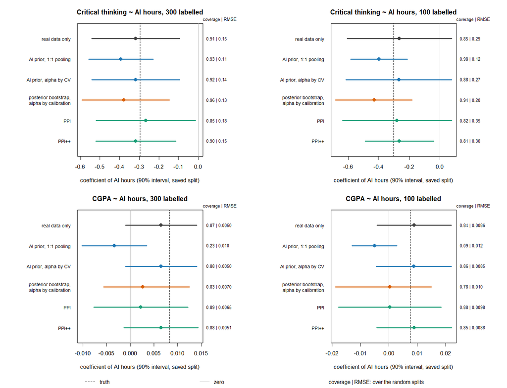

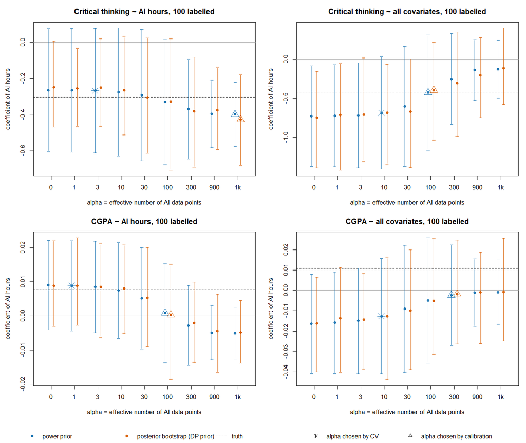

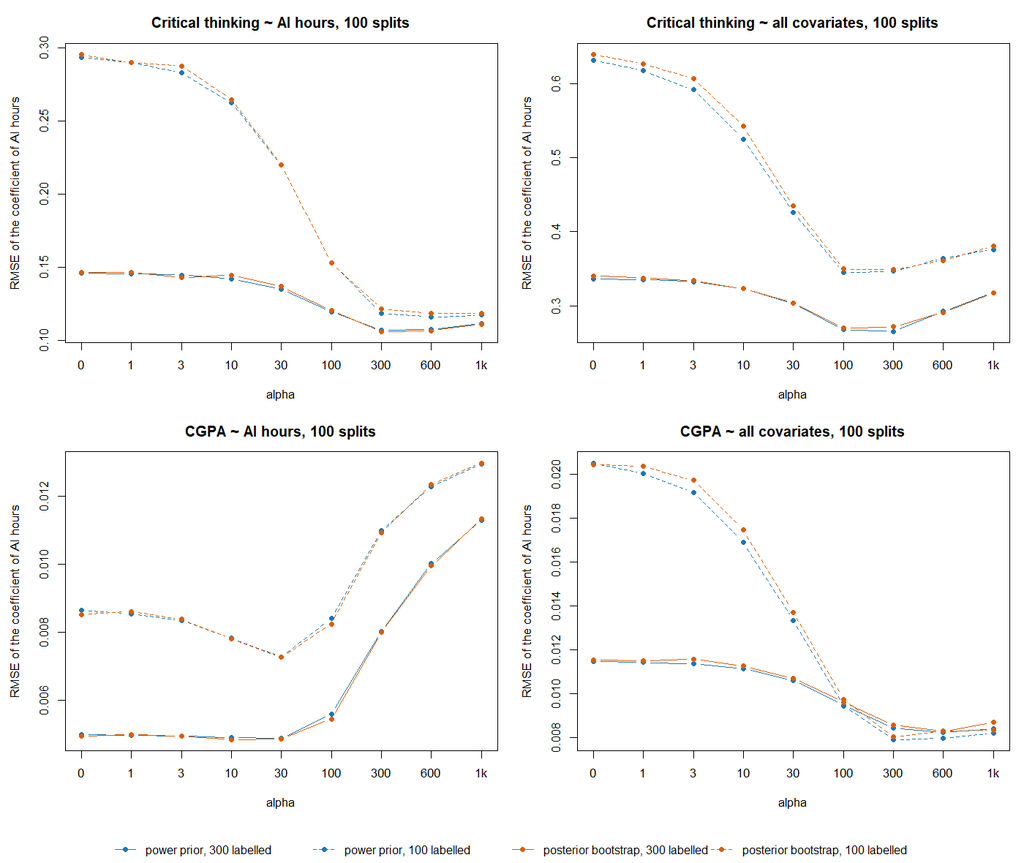

# 6 Limitations

- The dataset is synthetic (stated in its Kaggle description), so the LLM cannot have real-world knowledge about these students and the effects should not be read as real findings.
- The effects are weak (R² ≈ 1-2%), so the real data alone already give a wide interval.
- The LLM prior is only as good as the LLM and the prompt: v2 and v3 imply opposite effects of AI use on critical thinking.
- The LLM’s predictive distribution is elicited as probabilities over value ranges in one call; the paper’s view of the AI as a random label generator would suggest repeated prompting, which we did not do.
- The posterior is centred at a biased value whenever $\alpha > 0$ and the LLM is biased (paper, discussion after Theorem 1); the method does not correct this bias, it only limits its weight. PPI corrects it, but gains no precision when the LLM cannot predict individual students.

# 7 Reproducibility

- `data_check.R`: about 10 s. `regression_power_prior.R`: about 20 min, offline.
- `llm_prior_labels.R` / `llm_prior_labels_v3.R`: need `GROQ_API_KEY`; their outputs are saved in `data/llm/`.
- Set `rerun_analysis: true` in the header to recompute the 100-split study while knitting.

# 8 Appendix: full code

## 8.1 `regression/data_check.R`

```r
# ==========================================================================
# data_check.R -- STEP 1: is campus_ai_pulse_2026.csv fit for the
# linear-regression half of the AI-prior project (O'Hagan & Rockova 2025)?
#
# Read-only: does NOT modify bapr2.R or any data file.
# Writes plots + a summary table to ./data_check_output/
# Dependencies: base R (+ jsonlite, only for the LLM-response checks).
#
# Usage: put campus_ai_pulse_2026.csv (and optionally risposte_groq_oss20b.rds,
# data_ai_campus_complete.rds) in data/llm/, then from the project root:
#        source("regression/data_check.R")
# ==========================================================================

DATA_DIR <- Sys.getenv("CAMPUS_DATA_DIR", "data")                 # folder holding the csv
LLM_DIR  <- Sys.getenv("LLM_DIR", file.path(DATA_DIR, "llm"))     # folder holding the LLM .rds files
OUT_DIR  <- Sys.getenv("CHECK_OUT_DIR", file.path("regression", "output", "data_check"))
dir.create(OUT_DIR, showWarnings = FALSE, recursive = TRUE)

Y_SCORE <- "critical_thinking_score"
Y_GPA   <- "cgpa"
X_KEY   <- "ai_hours_per_week"
DROPPED <- c(1, 9, 13, 14, 19:24)                 # columns removed in bapr2.R

csv_file <- file.path(DATA_DIR, "campus_ai_pulse_2026.csv")
if (!file.exists(csv_file)) stop("Dataset not found: ", normalizePath(csv_file, mustWork = FALSE),
                                 "\nSet CAMPUS_DATA_DIR or copy the csv into the project folder.")

checks <- data.frame(check = character(), result = character(),
                     problem = character(), fix = character(), stringsAsFactors = FALSE)
add_check <- function(check, result, problem, fix = "") {
  checks[nrow(checks) + 1, ] <<- list(check, result, problem, fix)
  cat(sprintf("\n[%s] %s -> %s\n", problem, check, result))
}
section <- function(txt) cat("\n\n==========", txt, "==========\n")
skew <- function(x) { x <- x[!is.na(x)]; mean((x - mean(x))^3) / sd(x)^3 }
kurt <- function(x) { x <- x[!is.na(x)]; mean((x - mean(x))^4) / sd(x)^4 - 3 }

# --------------------------------------------------------------------------
section("A. SOURCE, COLUMNS, LEAKAGE")
# --------------------------------------------------------------------------
raw_chr <- read.csv(csv_file, stringsAsFactors = FALSE, colClasses = "character",
                    na.strings = character(0))            # untouched text, for code checks
raw     <- read.csv(csv_file, stringsAsFactors = TRUE)    # exactly as bapr2.R reads it

col_info <- data.frame(idx = seq_along(raw), name = names(raw),
                       class = sapply(raw, function(v) class(v)[1]),
                       n_unique = sapply(raw, function(v) length(unique(v))),
                       dropped_in_bapr2 = seq_along(raw) %in% DROPPED,
                       example = sapply(raw_chr, function(v) paste(head(unique(v), 3), collapse = " / ")),
                       row.names = NULL)
print(col_info, right = FALSE)
write.csv(col_info, file.path(OUT_DIR, "columns.csv"), row.names = FALSE)

for (v in c(Y_SCORE, Y_GPA, X_KEY))
  if (!v %in% names(raw)) stop("Expected column missing: ", v)
if (any(c(Y_SCORE, Y_GPA, X_KEY) %in% names(raw)[DROPPED]))
  add_check("bapr2 drop list", "drops an outcome or the key predictor!", "YES", "fix column indices")
add_check("Columns dropped by bapr2.R",
          paste(names(raw)[DROPPED], collapse = ", "), "CHECK",
          "drop by NAME, not position, and document why each is dropped")

# Leakage: how well does each column (kept or dropped) predict each outcome on its own?
leak <- do.call(rbind, lapply(setdiff(names(raw), c(Y_SCORE, Y_GPA)), function(v) {
  x <- raw[[v]]
  if (is.factor(x) && nlevels(x) > 0.5 * nrow(raw)) return(NULL)   # ID-like
  r2 <- function(y) summary(lm(raw[[y]] ~ x))$r.squared
  data.frame(column = v, dropped = v %in% names(raw)[DROPPED],
             R2_score = round(r2(Y_SCORE), 3), R2_cgpa = round(r2(Y_GPA), 3))
}))
leak <- leak[order(-pmax(leak$R2_score, leak$R2_cgpa)), ]
print(leak, row.names = FALSE)
write.csv(leak, file.path(OUT_DIR, "leakage_r2.csv"), row.names = FALSE)
sus <- leak[pmax(leak$R2_score, leak$R2_cgpa) > 0.5, ]
add_check("Leakage (single-column R2 > 0.5 for an outcome)",
          if (nrow(sus)) paste(sprintf("%s%s", sus$column, ifelse(sus$dropped, "(dropped)", "(KEPT)")), collapse = ", ") else "none",
          if (any(!sus$dropped)) "YES" else if (nrow(sus)) "OK (dropped)" else "no",
          if (any(!sus$dropped)) "remove kept columns derived from the outcome" else "")
cor_outcomes <- cor(raw[[Y_SCORE]], raw[[Y_GPA]])
add_check("cor(score, cgpa)", round(cor_outcomes, 3),
          if (abs(cor_outcomes) > 0.8) "YES" else "no",
          "bapr2 already excludes the other outcome via '- cgpa' / '- critical_thinking_score'")

# --------------------------------------------------------------------------
section("B. BASIC QUALITY")
# --------------------------------------------------------------------------
data <- raw[, -DROPPED]                       # same as bapr2.R
add_check("Dimensions (raw / after drop)",
          sprintf("%d x %d / %d x %d", nrow(raw), ncol(raw), nrow(data), ncol(data)), "no")

# 3. numeric columns read as factors
num_like <- names(raw_chr)[sapply(names(raw_chr), function(v) {
  x <- trimws(raw_chr[[v]]); x <- x[x != "" & !toupper(x) %in% c("NA", "N/A", "NAN")]
  is.factor(raw[[v]]) && length(x) > 0 && mean(!is.na(suppressWarnings(as.numeric(x)))) > 0.9
})]
add_check("Numeric columns wrongly read as factors", if (length(num_like)) paste(num_like, collapse = ", ") else "none",
          if (length(num_like)) "YES" else "no", "clean the bad codes, then as.numeric()")

# 4. missing / empty / sentinel codes / duplicates
na_codes <- c("", "NA", "N/A", "NAN", "NULL", "UNKNOWN", "NONE", "-", "?", "-1", "-999", "999")
miss <- sapply(raw_chr, function(v) sum(toupper(trimws(v)) %in% na_codes))
miss <- miss[miss > 0]
print(miss)
add_check("Missing / empty / sentinel codes", if (length(miss)) paste(names(miss), miss, sep = "=", collapse = ", ") else "none",
          if (length(miss)) "CHECK" else "no", "inspect; '-1'/'999' may be legitimate values")
dup_rows    <- sum(duplicated(raw))
dup_feat    <- sum(duplicated(raw[, -1]))       # ignoring the (assumed) ID column
dup_id      <- sum(duplicated(raw[[1]]))
add_check("Duplicated rows / rows dup. ignoring col 1 / dup. values in col 1",
          sprintf("%d / %d / %d", dup_rows, dup_feat, dup_id),
          if (dup_rows + dup_feat + dup_id > 0) "YES" else "no", "deduplicate before splitting")
```

```r
# 5. ranges
num_cols <- names(raw)[sapply(raw, is.numeric)]
rng <- data.frame(column = num_cols,
                  min = sapply(raw[num_cols], min, na.rm = TRUE),
                  median = sapply(raw[num_cols], median, na.rm = TRUE),
                  max = sapply(raw[num_cols], max, na.rm = TRUE),
                  n_neg = sapply(raw[num_cols], function(x) sum(x < 0, na.rm = TRUE)),
                  n_out_4sd = sapply(raw[num_cols], function(x) sum(abs(scale(x)) > 4, na.rm = TRUE)),
                  row.names = NULL)
print(rng)
write.csv(rng, file.path(OUT_DIR, "ranges.csv"), row.names = FALSE)
bad_gpa   <- sum(raw[[Y_GPA]] < 0 | raw[[Y_GPA]] > 4, na.rm = TRUE)
bad_score <- sum(raw[[Y_SCORE]] < 0 | raw[[Y_SCORE]] > 100, na.rm = TRUE)
bad_hours <- sum(raw[[X_KEY]] < 0 | raw[[X_KEY]] > 112, na.rm = TRUE)   # >16 h/day
add_check("Impossible values: cgpa outside 0-4 / score outside 0-100 / ai_hours <0 or >112",
          sprintf("%d / %d / %d", bad_gpa, bad_score, bad_hours),
          if (bad_gpa + bad_score + bad_hours) "YES" else "no", "remove or cap")
if ("age" %in% names(raw)) add_check("Age range", paste(range(raw$age, na.rm = TRUE), collapse = "-"),
                                     if (any(raw$age < 15 | raw$age > 80, na.rm = TRUE)) "YES" else "no")

# 6. distributions + 'synthetic fingerprints'
png(file.path(OUT_DIR, "distributions.png"), width = 1500, height = 500)
par(mfrow = c(1, 3))
for (v in c(Y_SCORE, Y_GPA, X_KEY)) {
  hist(raw[[v]], breaks = 40, main = v, xlab = v, col = "grey80", freq = FALSE)
  curve(dnorm(x, mean(raw[[v]]), sd(raw[[v]])), add = TRUE, col = "red", lwd = 2)
}
dev.off()
shape <- do.call(rbind, lapply(c(Y_SCORE, Y_GPA, X_KEY), function(v) {
  x <- raw[[v]]
  dec <- nchar(sub("^[^.]*\\.?", "", format(x, scientific = FALSE, trim = TRUE)))
  data.frame(variable = v, mean = mean(x), sd = sd(x), skew = round(skew(x), 2),
             ex_kurt = round(kurt(x), 2), n_unique = length(unique(x)),
             max_decimals = max(dec), pct_at_min = round(100 * mean(x == min(x)), 1),
             pct_at_max = round(100 * mean(x == max(x)), 1),
             ks_normal_p = signif(suppressWarnings(ks.test(scale(x), "pnorm")$p.value), 3),
             ks_uniform_p = signif(suppressWarnings(ks.test(x, "punif", min(x), max(x))$p.value), 3))
}))
print(shape, row.names = FALSE)
write.csv(shape, file.path(OUT_DIR, "shape.csv"), row.names = FALSE)
ceil <- shape$pct_at_min > 5 | shape$pct_at_max > 5
add_check("Ceiling / floor (>5% at min or max)", paste(shape$variable[ceil], collapse = ", "),
          if (any(ceil)) "YES" else "no", "consider censored/Tobit model or a transformation")
synth <- shape$variable[shape$ks_normal_p > 0.5 | shape$ks_uniform_p > 0.5]
add_check("Suspiciously perfect normal/uniform shape (KS p > 0.5)",
          if (length(synth)) paste(synth, collapse = ", ") else "none",
          if (length(synth)) "CHECK (synthetic?)" else "no")

# 7. rare factor levels
fac_cols <- names(data)[sapply(data, is.factor)]
rare <- unlist(lapply(fac_cols, function(v) {
  tb <- table(data[[v]]); r <- tb[tb < 10]
  if (length(r)) paste0(v, ":", names(r), "(", r, ")") else NULL
}))
for (v in fac_cols) { cat("\n", v, ":\n"); print(table(data[[v]])) }
add_check("Rare factor levels (<10 rows) in modelling data",
          if (length(rare)) paste(rare, collapse = ", ") else "none",
          if (length(rare)) "YES" else "no", "merge rare levels; lm() on a 300-row split can fail")
hi_card <- fac_cols[sapply(data[fac_cols], nlevels) > 20]
if (length(hi_card)) add_check("High-cardinality factors (>20 levels)", paste(hi_card, collapse = ", "),
                               "YES", "drop or group; huge number of dummies")

# --------------------------------------------------------------------------
section("C. SUITABILITY FOR LINEAR REGRESSION")
# --------------------------------------------------------------------------
num_d <- names(data)[sapply(data, is.numeric)]
cm <- cor(data[num_d])
print(round(cm, 2))
write.csv(round(cm, 3), file.path(OUT_DIR, "correlations.csv"))
png(file.path(OUT_DIR, "correlations.png"), width = 900, height = 900)
par(mar = c(10, 10, 2, 2))
image(1:ncol(cm), 1:ncol(cm), cm[, ncol(cm):1], zlim = c(-1, 1), axes = FALSE, xlab = "", ylab = "",
      col = hcl.colors(41, "Blue-Red 3"), main = "Correlations (numeric, kept columns)")
axis(1, 1:ncol(cm), colnames(cm), las = 2); axis(2, 1:ncol(cm), rev(colnames(cm)), las = 2)
text(rep(1:ncol(cm), ncol(cm)), rep(ncol(cm):1, each = ncol(cm)), sprintf("%.2f", cm), cex = 0.8)
dev.off()

# 8. VIF (generalised: 1/(1-R2) of each predictor on the others, numeric predictors)
preds <- setdiff(names(data), c(Y_SCORE, Y_GPA))
vif <- sapply(intersect(preds, num_d), function(v) {
  f <- reformulate(setdiff(preds, v), response = v)
  1 / (1 - summary(lm(f, data = data))$r.squared)
})
print(round(sort(vif, decreasing = TRUE), 2))
add_check("Max VIF (numeric predictors, given all others)",
          sprintf("%s = %.2f", names(which.max(vif)), max(vif)),
          if (max(vif) > 5) "YES" else "no", "drop/merge collinear predictors")

# 9-10. OLS for both outcomes
fit_models <- list(
  score_all  = lm(reformulate(setdiff(names(data), c(Y_SCORE, Y_GPA)), Y_SCORE), data = data),
  score_only = lm(reformulate(X_KEY, Y_SCORE), data = data),
  cgpa_all   = lm(reformulate(setdiff(names(data), c(Y_SCORE, Y_GPA)), Y_GPA), data = data),
  cgpa_only  = lm(reformulate(X_KEY, Y_GPA), data = data))
ols <- do.call(rbind, lapply(names(fit_models), function(m) {
  f <- fit_models[[m]]; s <- summary(f); ci <- confint(f)[X_KEY, ]
  data.frame(model = m, n = nobs(f), p = length(coef(f)) - 1,
             R2 = round(s$r.squared, 3), adjR2 = round(s$adj.r.squared, 3),
             sigma = signif(s$sigma, 3),
             beta_ai = signif(coef(f)[X_KEY], 3), ci_lo = signif(ci[1], 3), ci_hi = signif(ci[2], 3),
             t_ai = round(coef(s)[X_KEY, "t value"], 2),
             partial_R2_ai = round(coef(s)[X_KEY, "t value"]^2 /
                                   (coef(s)[X_KEY, "t value"]^2 + f$df.residual), 4),
             max_cook = round(max(cooks.distance(f), na.rm = TRUE), 3),
             n_cook_gt_4n = sum(cooks.distance(f) > 4 / nobs(f), na.rm = TRUE),
             shapiro_p = signif(shapiro.test(head(resid(f), 5000))$p.value, 3))
}))
print(ols, row.names = FALSE)
write.csv(ols, file.path(OUT_DIR, "ols_full_data.csv"), row.names = FALSE)
for (m in names(fit_models)) {
  png(file.path(OUT_DIR, paste0("residuals_", m, ".png")), width = 1000, height = 1000)
  par(mfrow = c(2, 2)); plot(fit_models[[m]], which = c(1, 2, 3, 4), main = m); dev.off()
}
for (i in seq_len(nrow(ols))) with(ols[i, ], add_check(
  sprintf("OLS %s: R2, beta_ai [95%% CI]", model),
  sprintf("R2=%.3f, beta=%s [%s, %s], partial R2(ai)=%.4f", R2, beta_ai, ci_lo, ci_hi, partial_R2_ai),
  if (R2 < 0.05 || (ci_lo < 0 & ci_hi > 0)) "YES (weak signal)" else "no",
  if (R2 < 0.05) "truth is ~noise: an LLM prior can only add bias; consider a different outcome/dataset" else ""))
```

```r
# 11. sample size: how precise is beta_ai at the planned n=300 labelled?
n_tot <- nrow(data)
se_at <- function(n, f) summary(f)$coef[X_KEY, "Std. Error"] * sqrt(nobs(f) / n)
ss <- do.call(rbind, lapply(names(fit_models), function(m) {
  f <- fit_models[[m]]; b <- coef(f)[X_KEY]
  data.frame(model = m, beta_full = signif(b, 3),
             se_n50 = signif(se_at(50, f), 3), se_n100 = signif(se_at(100, f), 3),
             se_n300 = signif(se_at(300, f), 3),
             z_at_n300 = round(b / se_at(300, f), 2))
}))
print(ss, row.names = FALSE)
write.csv(ss, file.path(OUT_DIR, "sample_size.csv"), row.names = FALSE)
add_check("Rows available vs 300 known + 900 AI",
          sprintf("%d rows; 1200 used; %d unused", n_tot, n_tot - 1200),
          if (n_tot < 1200) "YES" else "no",
          "smaller n_known (50-100) makes the prior's effect visible; keep a held-out test set")

# --------------------------------------------------------------------------
section("D. LLM-PRIOR CHECKS (only if files exist)")
# --------------------------------------------------------------------------
f_resp <- file.path(LLM_DIR, "risposte_groq_oss20b.rds")
f_comp <- file.path(LLM_DIR, "data_ai_campus_complete.rds")

if (file.exists(f_resp) && requireNamespace("jsonlite", quietly = TRUE)) {
  resp <- readRDS(f_resp)
  per_batch <- t(sapply(seq_along(resp), function(b) {
    r <- resp[b]
    if (is.na(r)) return(c(json_ok = 0, n_students = 0, n_valid = 0, bad_sum = 0))
    txt <- regmatches(r, regexpr("\\{[\\s\\S]*\\}", r, perl = TRUE))
    js <- if (length(txt)) tryCatch(jsonlite::fromJSON(txt, simplifyVector = FALSE), error = function(e) NULL)
    if (is.null(js$students)) return(c(json_ok = 0, n_students = 0, n_valid = 0, bad_sum = 0))
    ok <- sapply(js$students, function(s) length(unlist(s$cgpa)) == 8 && length(unlist(s$score)) == 10)
    sums <- unlist(lapply(js$students[ok], function(s) c(sum(unlist(s$cgpa)), sum(unlist(s$score)))))
    c(json_ok = 1, n_students = length(js$students), n_valid = sum(ok),
      bad_sum = sum(abs(sums - 1) > 0.05))
  }))
  print(colSums(per_batch))
  add_check("LLM responses: batches NA / bad JSON / students parsed / valid 8+10 bins / prob sums off by >0.05",
            sprintf("%d / %d / %d / %d / %d", sum(is.na(resp)), sum(per_batch[, "json_ok"] == 0 & !is.na(resp)),
                    sum(per_batch[, "n_students"]), sum(per_batch[, "n_valid"]), sum(per_batch[, "bad_sum"])),
            if (any(per_batch[, "json_ok"] == 0) || any(per_batch[, "n_students"] != 15)) "YES" else "no",
            "use response_format json_object; match students by 'id', not position")
}

if (file.exists(f_comp)) {
  ai <- readRDS(f_comp)
  # Recover the TRUE labels of the rows the LLM labelled, by matching on all feature columns.
  feats <- setdiff(names(ai), c(Y_SCORE, Y_GPA))
  key  <- function(d) do.call(paste, c(lapply(d[feats], as.character), sep = "|"))
  truth_idx <- match(key(ai), key(data))
  add_check("AI rows matched back to original data", sprintf("%d / %d (ambiguous dup keys: %d)",
            sum(!is.na(truth_idx)), nrow(ai), sum(duplicated(key(data)))),
            if (anyNA(truth_idx)) "YES" else "no")
  add_check("NA in LLM-imputed labels (cgpa / score)",
            sprintf("%d / %d", sum(is.na(ai[[Y_GPA]])), sum(is.na(ai[[Y_SCORE]]))),
            if (anyNA(ai[[Y_GPA]]) || anyNA(ai[[Y_SCORE]])) "YES" else "no", "lm() silently drops them")
  cmp <- do.call(rbind, lapply(c(Y_SCORE, Y_GPA), function(y) {
    a <- ai[[y]]; t <- data[[y]][truth_idx]; ok <- !is.na(a) & !is.na(t)
    data.frame(outcome = y, mean_llm = mean(a[ok]), mean_true = mean(t[ok]),
               sd_llm = sd(a[ok]), sd_true = sd(t[ok]),
               cor = round(cor(a[ok], t[ok]), 3), mse = mean((a[ok] - t[ok])^2),
               mse_predict_mean = mean((mean(t[ok]) - t[ok])^2))
  }))
  print(cmp, row.names = FALSE)
  write.csv(cmp, file.path(OUT_DIR, "llm_vs_true.csv"), row.names = FALSE)
  for (i in seq_len(nrow(cmp))) with(cmp[i, ], add_check(
    sprintf("LLM vs true %s: cor, MSE (vs MSE of predicting the mean)", outcome),
    sprintf("cor=%.3f, MSE=%.3g (baseline %.3g), mean %.3g vs %.3g, sd %.3g vs %.3g",
            cor, mse, mse_predict_mean, mean_llm, mean_true, sd_llm, sd_true),
    if (cor < 0.2 || mse > mse_predict_mean) "YES" else "no",
    "LLM labels carry little information; prior will mostly add noise/bias"))
  png(file.path(OUT_DIR, "llm_vs_true.png"), width = 1000, height = 500)
  par(mfrow = c(1, 2))
  for (y in c(Y_SCORE, Y_GPA)) { plot(data[[y]][truth_idx], ai[[y]], xlab = "true", ylab = "LLM-imputed",
                                      main = y, pch = 16, col = "#00000040"); abline(0, 1, col = "red") }
  dev.off()
}
add_check("Split reproducibility in bapr2.R",
          "sample() is called before set.seed(30175)", "YES",
          "move set.seed() above the shuffle; otherwise cached LLM labels get attached to different rows on every run")

# --------------------------------------------------------------------------
section("SUMMARY TABLE")
# --------------------------------------------------------------------------
print(checks, right = FALSE, row.names = FALSE)
write.csv(checks, file.path(OUT_DIR, "summary_checks.csv"), row.names = FALSE)
cat("\nOutputs written to", normalizePath(OUT_DIR), "\n")
```

## 8.2 `regression/llm_prior_labels.R`

```r
# ==========================================================================
# llm_prior_labels.R -- regenerate the LLM-imputed labels for the AI rows.
#
# Same idea as sections 2 and 4-7 of bapr2.R (bapr2.R itself is NOT modified), with fixes:
#   * set.seed() BEFORE the shuffle; the split (student_ids) is saved and checked
#   * API key read from the environment (GROQ_API_KEY), never written in code
#   * students sent with their real student_id and matched back BY ID, not position
#   * JSON mode + larger max_tokens (gpt-oss reasoning tokens count toward it)
#   * 401/403/404 stop the script instead of silently producing NA
#   * batches with missing students or 15 identical answers are retried
#   * full per-student probabilities are saved, not just one sampled value
#   * new file names (*_v2.rds): the old risposte_groq_oss20b.rds is never touched
#
# Setup: add GROQ_API_KEY=... to ~/.Renviron (not in the repo), restart R,
#        renv::install("httr") once (bapr2.R needs it too).
# Run:   source("regression/llm_prior_labels.R")  (from the project root) -- resumes from the cache
# Test:  Sys.setenv(LLM_DRY_RUN = "1") -- fake LLM answers, no API calls, tag "dryrun"
# ==========================================================================

library(jsonlite)

DATA_DIR   <- Sys.getenv("CAMPUS_DATA_DIR", "data")                   # where the csv is
OUT_DIR    <- Sys.getenv("LLM_OUT_DIR", file.path(DATA_DIR, "llm"))   # where the LLM outputs go
dir.create(OUT_DIR, showWarnings = FALSE, recursive = TRUE)
DRY_RUN    <- identical(Sys.getenv("LLM_DRY_RUN"), "1")
OUT_TAG    <- if (DRY_RUN) "dryrun" else "v2"

SEED       <- 30175
N_KNOWN    <- 300
N_AI       <- 900
BATCH_SIZE <- 15
MAX_TRIES  <- 3        # per batch, when the answer is incomplete or degenerate

MODEL_ID   <- "openai/gpt-oss-20b"
ENDPOINT   <- "https://api.groq.com/openai/v1/chat/completions"

# Same columns bapr2.R drops (positions 9, 13, 14, 19-24), by NAME. student_id is kept as the key.
DROP_COLS <- c("uses_ai", "paid_ai_subscription", "prompt_skill_level", "time_saved_pct",
               "ai_dependency_score", "ai_dependency_level", "integrity_concern_level",
               "flagged_by_ai_detector", "would_recommend_ai")
OUTCOMES  <- c("cgpa", "critical_thinking_score")

out_file <- function(name) file.path(OUT_DIR, paste0(name, "_", OUT_TAG, ".rds"))

# --------------------------------------------------------------------------
# 1. Data + reproducible split
# --------------------------------------------------------------------------
data <- read.csv(file.path(DATA_DIR, "campus_ai_pulse_2026.csv"), stringsAsFactors = TRUE)
stopifnot(all(DROP_COLS %in% names(data)), !anyDuplicated(data$student_id),
          N_KNOWN + N_AI <= nrow(data))
data <- data[, setdiff(names(data), DROP_COLS)]
data$student_id <- as.character(data$student_id)

set.seed(SEED)
perm  <- sample(nrow(data))
split <- list(seed = SEED,
              known_ids = data$student_id[perm[seq_len(N_KNOWN)]],
              ai_ids    = data$student_id[perm[N_KNOWN + seq_len(N_AI)]],
              test_ids  = data$student_id[perm[-seq_len(N_KNOWN + N_AI)]])

f_split <- out_file("llm_split")
if (file.exists(f_split)) {
  old <- readRDS(f_split)
  if (!identical(old[c("known_ids", "ai_ids")], split[c("known_ids", "ai_ids")]))
    stop("Split differs from the saved one in ", f_split,
         " (different seed/R version/N_KNOWN?). Cached LLM answers would not match. ",
         "Use a new OUT_TAG or delete the cache deliberately.")
} else saveRDS(split, f_split)

data_known  <- data[match(split$known_ids, data$student_id), ]
data_ai_raw <- data[match(split$ai_ids, data$student_id), setdiff(names(data), OUTCOMES)]
feature_cols <- setdiff(names(data_ai_raw), "student_id")

# --------------------------------------------------------------------------
# 2. Prompt
# --------------------------------------------------------------------------
GPA_LO   <- seq(0, 3.5, 0.5); GPA_HI   <- GPA_LO + 0.5
SCORE_LO <- seq(0, 90, 10);   SCORE_HI <- SCORE_LO + 10

create_batch_prompt <- function(d) {
  rows <- vapply(seq_len(nrow(d)), function(i)
    paste(c(d$student_id[i], vapply(feature_cols, function(v) as.character(d[[v]][i]), "")),
          collapse = "|"), "")
  paste0(
    "You are an educational data analyst. For each university student below, give your predictive ",
    "probability distribution for two outcomes, based only on that student's own features.\n",
    "1) \"cgpa\" (0-4 scale): 8 probabilities for bins ",
    "[0.0-0.5, 0.5-1.0, 1.0-1.5, 1.5-2.0, 2.0-2.5, 2.5-3.0, 3.0-3.5, 3.5-4.0]\n",
    "2) \"score\" (critical thinking score, 0-100): 10 probabilities for bins ",
    "[0-10, 10-20, 20-30, 30-40, 40-50, 50-60, 60-70, 70-80, 80-90, 90-100]\n",
    "Each list must sum to 1. Reflect your real uncertainty and judge each student individually.\n",
    "Columns: id|", paste(feature_cols, collapse = "|"), "\n",
    "Return only a JSON object {\"students\": [{\"id\": \"<id>\", \"cgpa\": [8 numbers], ",
    "\"score\": [10 numbers]}, ...]} with exactly one entry per student, using the ids given.\n\n",
    paste(rows, collapse = "\n"))
}

# --------------------------------------------------------------------------
# 3. API call (or a fake one for DRY_RUN)
# --------------------------------------------------------------------------
get_response <- function(prompt_text) {
  if (DRY_RUN) {                                   # random but valid answers, no network
    ids <- sub("\\|.*$", "", grep("^S[0-9]+\\|", strsplit(prompt_text, "\n")[[1]], value = TRUE))
    rd  <- function(k) { x <- rgamma(k, 1); round(x / sum(x), 3) }
    return(as.character(toJSON(list(students = lapply(ids, function(id)
      list(id = id, cgpa = rd(8), score = rd(10)))), auto_unbox = TRUE)))
  }
  key <- Sys.getenv("GROQ_API_KEY")
  if (!nzchar(key)) stop("GROQ_API_KEY is not set. Put it in ~/.Renviron and restart R.")
  body <- toJSON(list(model = MODEL_ID,
                      messages = list(list(role = "user", content = prompt_text)),
                      temperature = 0.4, max_tokens = 6000, reasoning_effort = "low",
                      response_format = list(type = "json_object")), auto_unbox = TRUE)
  for (attempt in 1:5) {
    resp <- tryCatch(httr::POST(ENDPOINT, body = body, encode = "raw",
                                httr::add_headers(Authorization = paste("Bearer", key),
                                                  `Content-Type` = "application/json")),
                     error = function(e) { cat("  [connection error]", conditionMessage(e), "\n"); NULL })
    if (is.null(resp)) { Sys.sleep(5); next }
    sc  <- httr::status_code(resp)
    txt <- httr::content(resp, "text", encoding = "UTF-8")
    if (sc == 200) {
      out <- tryCatch(fromJSON(txt, simplifyVector = FALSE)$choices[[1]]$message$content,
                      error = function(e) NULL)
      if (length(out) && nzchar(trimws(out))) return(out)
      cat("  [empty answer]\n")
    } else if (sc %in% c(401, 403, 404)) {
      stop("Groq returned HTTP ", sc, " (bad/revoked key or wrong model): ", substr(txt, 1, 300))
    } else if (sc == 429) {
      if (grepl("tokens per day|TPD", txt, ignore.case = TRUE)) return("TPD_LIMIT")
      cat("  [rate limit] waiting 15s\n"); Sys.sleep(15)
    } else {
      cat("  [HTTP", sc, "]", substr(txt, 1, 200), "\n"); Sys.sleep(3)
    }
  }
  NA_character_
}
```

```r
# --------------------------------------------------------------------------
# 4. Parse + validate one batch answer -> one row of probabilities per student
# --------------------------------------------------------------------------
P_GPA   <- paste0("p_cgpa_", 1:8)
P_SCORE <- paste0("p_score_", 1:10)

parse_batch <- function(txt, ids) {
  if (is.na(txt)) return(NULL)
  json <- regmatches(txt, regexpr("\\{[\\s\\S]*\\}", txt, perl = TRUE))
  js <- if (length(json)) tryCatch(fromJSON(json, simplifyVector = FALSE), error = function(e) NULL)
  if (is.null(js$students)) return(NULL)
  rows <- lapply(js$students, function(s) {
    g  <- suppressWarnings(as.numeric(unlist(s$cgpa)))
    sc <- suppressWarnings(as.numeric(unlist(s$score)))
    if (is.null(s$id) || length(g) != 8 || length(sc) != 10 || anyNA(c(g, sc)) ||
        any(c(g, sc) < 0) || sum(g) <= 0 || sum(sc) <= 0) return(NULL)
    r <- data.frame(student_id = as.character(s$id), sum_cgpa_raw = sum(g), sum_score_raw = sum(sc))
    r[P_GPA] <- as.list(g / sum(g)); r[P_SCORE] <- as.list(sc / sum(sc))
    r
  })
  P <- do.call(rbind, rows)
  if (is.null(P)) return(NULL)
  P[P$student_id %in% ids & !duplicated(P$student_id), ]
}

batch_ok <- function(P, ids) !is.null(P) && setequal(P$student_id, ids) &&
  (length(ids) == 1 || nrow(unique(round(P[c(P_GPA, P_SCORE)], 3))) > 1)

# --------------------------------------------------------------------------
# 5. Run all batches, resuming from the cache
# --------------------------------------------------------------------------
batches  <- split(split$ai_ids, ceiling(seq_along(split$ai_ids) / BATCH_SIZE))
f_cache  <- out_file("llm_responses")
cache    <- if (file.exists(f_cache)) readRDS(f_cache) else vector("list", length(batches))

for (b in seq_along(batches)) {
  ids <- batches[[b]]
  if (!is.null(cache[[b]]) && identical(cache[[b]]$ids, ids) && cache[[b]]$ok) next
  d <- data_ai_raw[match(ids, data_ai_raw$student_id), ]
  best <- list(ids = ids, text = NA_character_, ok = FALSE, n_valid = 0, tries = 0)
  for (try in seq_len(MAX_TRIES)) {
    cat(sprintf("Batch %d/%d, try %d ...\n", b, length(batches), try))
    txt <- get_response(create_batch_prompt(d))
    if (identical(txt, "TPD_LIMIT")) {
      saveRDS(cache, f_cache)
      stop("Daily token limit reached. Progress saved in ", f_cache, "; re-run tomorrow to resume.")
    }
    P  <- parse_batch(txt, ids)
    nv <- if (is.null(P)) 0 else nrow(P)
    if (nv >= best$n_valid) best <- list(ids = ids, text = txt, ok = batch_ok(P, ids),
                                         n_valid = nv, tries = try)
    if (best$ok) break
    cat("  incomplete or degenerate answer (", nv, "/", length(ids), "valid ) - retrying\n")
  }
  cache[[b]] <- best
  saveRDS(cache, f_cache)
  if (!DRY_RUN) Sys.sleep(2.5)
}

# --------------------------------------------------------------------------
# 6. Probabilities, sampled labels (as in bapr2.R), and the AI dataset
# --------------------------------------------------------------------------
probs <- do.call(rbind, lapply(cache, function(cb) parse_batch(cb$text, cb$ids)))
probs <- probs[match(split$ai_ids, probs$student_id), ]
probs$student_id <- split$ai_ids                         # unmatched students stay as NA rows
probs$exp_cgpa  <- as.vector(as.matrix(probs[P_GPA])   %*% ((GPA_LO + GPA_HI) / 2))
probs$exp_score <- as.vector(as.matrix(probs[P_SCORE]) %*% ((SCORE_LO + SCORE_HI) / 2))
saveRDS(probs, out_file("llm_probs"))

set.seed(SEED)
draw <- function(p, lo, hi) {
  if (anyNA(p)) return(NA_real_)
  k <- sample(length(p), 1, prob = p); runif(1, lo[k], hi[k])
}
data_ai_complete <- data_ai_raw
data_ai_complete$cgpa <- round(apply(probs[P_GPA], 1, draw, GPA_LO, GPA_HI), 2)
data_ai_complete$critical_thinking_score <- round(apply(probs[P_SCORE], 1, draw, SCORE_LO, SCORE_HI), 1)
saveRDS(data_ai_complete, out_file("data_ai_complete"))
saveRDS(data_known, out_file("data_known"))

# --------------------------------------------------------------------------
# 7. Quality report (true labels used ONLY here, for evaluation)
# --------------------------------------------------------------------------
truth <- data[match(split$ai_ids, data$student_id), ]
ok    <- !is.na(probs$exp_cgpa)
one_hot <- function(cols) sum(apply(probs[ok, cols], 1, max) > 0.99)
cat("\n===== LLM label quality (", OUT_TAG, ") =====\n")
cat("Batches OK:", sum(vapply(cache, function(cb) isTRUE(cb$ok), TRUE)), "/", length(batches),
    " | students with valid answers:", sum(ok), "/", N_AI, "\n")
cat("Raw prob sums off by >5%:", sum(abs(probs$sum_cgpa_raw[ok] - 1) > 0.05 |
                                     abs(probs$sum_score_raw[ok] - 1) > 0.05),
    " | one-hot cgpa:", one_hot(P_GPA), " one-hot score:", one_hot(P_SCORE), "\n")
qual <- data.frame(
  outcome    = OUTCOMES,
  mean_llm   = c(mean(probs$exp_cgpa[ok]), mean(probs$exp_score[ok])),
  mean_true  = c(mean(truth$cgpa[ok]), mean(truth$critical_thinking_score[ok])),
  sd_llm     = c(sd(probs$exp_cgpa[ok]), sd(probs$exp_score[ok])),
  sd_true    = c(sd(truth$cgpa[ok]), sd(truth$critical_thinking_score[ok])),
  cor        = c(cor(probs$exp_cgpa[ok], truth$cgpa[ok]),
                 cor(probs$exp_score[ok], truth$critical_thinking_score[ok])),
  mse_llm    = c(mean((probs$exp_cgpa[ok] - truth$cgpa[ok])^2),
                 mean((probs$exp_score[ok] - truth$critical_thinking_score[ok])^2)),
  mse_mean   = c(var(truth$cgpa[ok]), var(truth$critical_thinking_score[ok])))
print(qual, digits = 3, row.names = FALSE)
cat("(mse_mean = error of always predicting the true mean; mse_llm should be below it)\n")
cat("Outputs:", paste(basename(c(f_split, f_cache, out_file("llm_probs"),
                                 out_file("data_ai_complete"), out_file("data_known"))),
                      collapse = ", "), "in", normalizePath(OUT_DIR), "\n")
```

## 8.3 `regression/llm_prior_labels_v3.R`

```r
# ==========================================================================
# llm_prior_labels_v3.R -- second LLM labelling run, in the style of the paper
# (O'Hagan & Rockova 2025, Sec. 5.1.2 and Appendix A.1):
#   * ONE student per API call (v2 used batches of 15)
#   * detailed prompt that explains every feature and both outcome scales
#   * temperature 0.7 and medium reasoning effort (as with the paper's o4-mini; v2: 0.4, low)
#   * larger model: openai/gpt-oss-120b (v2: gpt-oss-20b)
#   * the full probability distribution per student is kept (paper: AI base measure F_AI)
# Labels the SAME 900 AI students as v2 (read from data/llm/llm_split_v2.rds),
# so v2 and v3 can be compared directly. v2 files are never modified.
#
# Two targets (Sys.setenv(LLM_TARGET = ...)):
#   "ai"    (default) the 900 unlabelled students -> the AI prior
#   "known" the 300 labelled students -> LLM predictions needed for the PPI comparison
#           (paper Sec. 5.4 compares its method with prediction-powered inference)
#
# Two providers for the SAME model (Sys.setenv(LLM_PROVIDER = ...)):
#   "groq"       (default) Groq API directly, free tier; key GROQ_API_KEY
#   "openrouter" OpenRouter, paid, requests pinned to Groq's endpoint so the model and serving
#                stack stay the same as for the first 611 students; key OPENROUTER_API_KEY
# Every answer records which provider and model produced it.
#
# Run (from the project root, in RStudio):  source("regression/llm_prior_labels_v3.R")
#   It saves progress every 10 students and resumes where it stopped if run again.
# Test without API calls:  Sys.setenv(LLM_DRY_RUN = "1")
# ==========================================================================

library(jsonlite)

DATA_DIR    <- Sys.getenv("CAMPUS_DATA_DIR", "data")
LLM_DIR     <- Sys.getenv("LLM_DIR", file.path(DATA_DIR, "llm"))
OUT_DIR     <- Sys.getenv("LLM_OUT_DIR", LLM_DIR)
DRY_RUN     <- identical(Sys.getenv("LLM_DRY_RUN"), "1")
OUT_TAG     <- if (DRY_RUN) "v3dry" else "v3"
SPLIT_TAG   <- "v2"                                  # reuse the v2 split: same students
TARGET      <- Sys.getenv("LLM_TARGET", "ai")        # "ai" or "known"
PROVIDER    <- Sys.getenv("LLM_PROVIDER", "groq")    # "groq" or "openrouter"
stopifnot(TARGET %in% c("ai", "known"), PROVIDER %in% c("groq", "openrouter"))

SEED        <- 30175
# The paper used OpenAI o4-mini (a reasoning model, default reasoning effort "medium") at
# temperature 0.7. o4-mini is not on Groq; gpt-oss-120b is OpenAI's open-weight reasoning model.
MODEL_ID    <- Sys.getenv("LLM_MODEL", "openai/gpt-oss-120b")
TEMPERATURE <- 0.7
REASONING   <- Sys.getenv("LLM_REASONING", "medium")
MAX_TRIES   <- 3          # per student, if the answer is not valid JSON with 8 + 10 numbers
SAVE_EVERY  <- 10

API <- switch(PROVIDER,
  groq = list(endpoint = "https://api.groq.com/openai/v1/chat/completions",
              models   = "https://api.groq.com/openai/v1/models",
              key_var  = "GROQ_API_KEY", sleep = 2.5),
  openrouter = list(endpoint = "https://openrouter.ai/api/v1/chat/completions",
                    models   = "https://openrouter.ai/api/v1/models",
                    key_info = "https://openrouter.ai/api/v1/key",
                    key_var  = "OPENROUTER_API_KEY", sleep = 0.3,
                    order    = Sys.getenv("LLM_PROVIDER_ORDER", "groq")))   # serve via Groq
SLEEP_SEC <- as.numeric(Sys.getenv("LLM_SLEEP", API$sleep))

DROP_COLS <- c("uses_ai", "paid_ai_subscription", "prompt_skill_level", "time_saved_pct",
               "ai_dependency_score", "ai_dependency_level", "integrity_concern_level",
               "flagged_by_ai_detector", "would_recommend_ai")      # same features as v2
OUTCOMES  <- c("cgpa", "critical_thinking_score")
dir.create(OUT_DIR, showWarnings = FALSE, recursive = TRUE)
sfx      <- if (TARGET == "known") "_known" else ""
out_file <- function(name) file.path(OUT_DIR, paste0(name, sfx, "_", OUT_TAG, ".rds"))

# --------------------------------------------------------------------------
# 1. Data and the (unchanged) v2 split
# --------------------------------------------------------------------------
data <- read.csv(file.path(DATA_DIR, "campus_ai_pulse_2026.csv"), stringsAsFactors = TRUE)
data <- data[, setdiff(names(data), DROP_COLS)]
data$student_id <- as.character(data$student_id)

split <- readRDS(file.path(LLM_DIR, paste0("llm_split_", SPLIT_TAG, ".rds")))
if (TARGET == "ai") saveRDS(split, file.path(OUT_DIR, paste0("llm_split_", OUT_TAG, ".rds")))
target_ids  <- if (TARGET == "ai") split$ai_ids else split$known_ids
data_target <- data[match(target_ids, data$student_id), setdiff(names(data), OUTCOMES)]
feature_cols <- setdiff(names(data_target), "student_id")

# --------------------------------------------------------------------------
# 2. Detailed prompt (paper style: explain the inputs, one case per prompt) -- unchanged
# --------------------------------------------------------------------------
FEATURE_DESC <- c(
  age                     = "age in years",
  gender                  = "gender",
  country                 = "country where the student studies",
  university_type         = "Public or Private university",
  program                 = "field of study",
  year_of_study           = "year of study (1 = first year, ..., 4 = fourth year)",
  uni_ai_policy           = "the university's policy on using AI tools in coursework",
  primary_ai_tool         = "the AI tool the student uses most ('No AI tool' = the student does not use AI)",
  primary_use_case        = "what the student mainly uses AI for ('No AI use' = the student does not use AI)",
  ai_hours_per_week       = "hours per week the student spends using AI tools",
  ai_assignment_share_pct = "percentage (0-100) of the student's assignment work done with AI help",
  study_hours_per_week    = "hours per week of independent study")
stopifnot(all(feature_cols %in% names(FEATURE_DESC)))

# Same structure as the paper's prompt (Appendix A.1): role and task -> how to read the input
# -> meaning and scale of every feature -> what to estimate -> output format.
# Deliberate difference: the paper adds "Detailed Disease Profiles" (expert guidance on how each
# feature relates to each class). The analogue here would be telling the LLM how AI use affects
# grades, i.e. writing our own answer into the prior, so the LLM must rely on its own knowledge.
SYSTEM_PROMPT <- paste0(
  "You are an advanced AI educational assessment assistant. Your current task is to analyze a set ",
  "of characteristics of a university student, related to their study habits and their use of ",
  "generative AI tools, and estimate the probability distribution of two academic outcomes for this ",
  "student. Your analysis should be based on a deep understanding of how these characteristics ",
  "typically relate to students' academic performance. The input will be a list of characteristics ",
  "with their values for ONE student. Pay close attention to the meaning and scale of each one and ",
  "judge this student individually.\n\n",
  "Understanding the Input Features:\n",
  paste0(feature_cols, ": ", FEATURE_DESC[feature_cols], ".", collapse = "\n"), "\n\n",
  "Outcomes to Estimate:\n",
  "cgpa: the student's cumulative grade point average on a 0-4 scale. Estimate the probability that ",
  "it falls in each of 8 bins: [0.0-0.5, 0.5-1.0, 1.0-1.5, 1.5-2.0, 2.0-2.5, 2.5-3.0, 3.0-3.5, 3.5-4.0].\n",
  "score: the student's score on a standardised critical-thinking assessment on a 0-100 scale. ",
  "Estimate the probability that it falls in each of 10 bins: ",
  "[0-10, 10-20, 20-30, 30-40, 40-50, 50-60, 60-70, 70-80, 80-90, 90-100].\n",
  "Each set of probabilities must sum to 1 and should reflect your genuine uncertainty.\n\n",
  "Output Format:\n",
  "Return ONLY a JSON object of the form {\"cgpa\": [8 probabilities], \"score\": [10 probabilities]}, ",
  "with the probabilities in the bin order given above and no other text.")
```

```r
student_text <- function(i) paste0("Student:\n",
  paste0(feature_cols, ": ", vapply(feature_cols, function(v) as.character(data_target[[v]][i]), ""),
         collapse = "\n"))

# --------------------------------------------------------------------------
# 3. API
# --------------------------------------------------------------------------
api_key <- function() {
  key <- Sys.getenv(API$key_var)
  if (!nzchar(key)) stop(API$key_var, " is not set. Put it in ~/.Renviron and restart R.")
  key
}

check_model <- function() {
  key <- api_key()
  r <- httr::GET(API$models, httr::add_headers(Authorization = paste("Bearer", key)))
  if (httr::status_code(r) != 200)
    stop("Could not list models (HTTP ", httr::status_code(r), "): ",
         substr(httr::content(r, "text", encoding = "UTF-8"), 1, 300))
  ids <- vapply(fromJSON(httr::content(r, "text", encoding = "UTF-8"), simplifyVector = FALSE)$data,
                function(m) m$id, "")
  if (!MODEL_ID %in% ids)
    stop("Model '", MODEL_ID, "' is not available from ", PROVIDER, ".")
  if (PROVIDER == "openrouter") {                     # is the key valid, and what is its limit?
    k <- httr::GET(API$key_info, httr::add_headers(Authorization = paste("Bearer", key)))
    if (httr::status_code(k) == 401) stop("OpenRouter rejected the key (HTTP 401). Check OPENROUTER_API_KEY.")
    if (httr::status_code(k) == 200) {
      info <- fromJSON(httr::content(k, "text", encoding = "UTF-8"))$data
      cat("OpenRouter key OK. Usage so far: $", format(info$usage), " | limit: ",
          if (is.null(info$limit)) "none set" else paste0("$", info$limit), "\n", sep = "")
    }
    cat("Requests are pinned to provider:", API$order, "(no fallback to other providers)\n")
  }
  cat("Model", MODEL_ID, "is available via", PROVIDER, ".\n")
}

get_response <- function(user_text) {
  if (DRY_RUN) {                                        # fake valid answer, no network
    rd <- function(k) { x <- rgamma(k, 1); round(x / sum(x), 3) }
    return(as.character(toJSON(list(cgpa = rd(8), score = rd(10)), auto_unbox = TRUE)))
  }
  key <- api_key()
  req <- list(model = MODEL_ID,
              messages = list(list(role = "system", content = SYSTEM_PROMPT),
                              list(role = "user", content = user_text)),
              temperature = TEMPERATURE, max_tokens = 4000,
              response_format = list(type = "json_object"))
  if (PROVIDER == "groq") {
    req$reasoning_effort <- REASONING
  } else {
    req$reasoning <- list(effort = REASONING)
    req$provider  <- list(order = as.list(API$order), allow_fallbacks = FALSE)
  }
  body <- toJSON(req, auto_unbox = TRUE)
  for (attempt in 1:5) {
    resp <- tryCatch(httr::POST(API$endpoint, body = body, encode = "raw",
                                httr::add_headers(Authorization = paste("Bearer", key),
                                                  `Content-Type` = "application/json")),
                     error = function(e) { cat("  [connection error]", conditionMessage(e), "\n"); NULL })
    if (is.null(resp)) { Sys.sleep(10); next }
    sc  <- httr::status_code(resp)
    txt <- httr::content(resp, "text", encoding = "UTF-8")
    if (sc == 200) {
      js  <- tryCatch(fromJSON(txt, simplifyVector = FALSE), error = function(e) NULL)
      out <- tryCatch(js$choices[[1]]$message$content, error = function(e) NULL)
      if (length(out) && nzchar(trimws(out))) return(out)
      cat("  [empty answer]", substr(txt, 1, 150), "\n"); Sys.sleep(3)
    } else if (sc == 402) {
      stop(PROVIDER, ": not enough credit (HTTP 402). Add credit and run the same line again.")
    } else if (sc %in% c(401, 403, 404)) {
      stop(PROVIDER, " returned HTTP ", sc, " (bad key or wrong model): ", substr(txt, 1, 300))
    } else if (sc == 429) {
      if (PROVIDER == "groq" && grepl("tokens per day|TPD|requests per day|RPD", txt, ignore.case = TRUE))
        return("DAILY_LIMIT")
      cat("  [rate limit] waiting 20s\n"); Sys.sleep(20)
    } else {
      cat("  [HTTP", sc, "]", substr(txt, 1, 150), "\n"); Sys.sleep(5)
    }
  }
  NA_character_
}

P_GPA <- paste0("p_cgpa_", 1:8); P_SCORE <- paste0("p_score_", 1:10)
parse_one <- function(txt) {
  if (is.null(txt) || is.na(txt)) return(NULL)
  json <- regmatches(txt, regexpr("\\{[\\s\\S]*\\}", txt, perl = TRUE))
  js <- if (length(json)) tryCatch(fromJSON(json, simplifyVector = FALSE), error = function(e) NULL)
  g  <- suppressWarnings(as.numeric(unlist(js$cgpa)))
  sc <- suppressWarnings(as.numeric(unlist(js$score)))
  if (length(g) != 8 || length(sc) != 10 || anyNA(c(g, sc)) || any(c(g, sc) < 0) ||
      sum(g) <= 0 || sum(sc) <= 0) return(NULL)
  c(sum_cgpa_raw = sum(g), sum_score_raw = sum(sc),
    setNames(g / sum(g), P_GPA), setNames(sc / sum(sc), P_SCORE))
}

# --------------------------------------------------------------------------
# 4. Run: one call per student, resuming from the cache
# --------------------------------------------------------------------------
if (!DRY_RUN) check_model()
cat("Target:", TARGET, "students | provider:", PROVIDER, "| model:", MODEL_ID, "\n")
cat("System prompt sent with every call:\n----\n", SYSTEM_PROMPT, "\n----\n", sep = "")

f_cache <- out_file("llm_responses")
cache   <- if (file.exists(f_cache)) readRDS(f_cache) else list()
todo    <- which(!vapply(target_ids, function(id) isTRUE(cache[[id]]$ok), TRUE))
cat(length(target_ids) - length(todo), "of", length(target_ids), TARGET, "students already done;",
    length(todo), "to go.\n")

t0 <- Sys.time(); n_done <- 0
for (i in todo) {
  id <- target_ids[i]; best <- list(text = NA_character_, ok = FALSE, tries = 0)
  for (try in seq_len(MAX_TRIES)) {
    txt <- get_response(student_text(i))
    if (identical(txt, "DAILY_LIMIT")) {
      saveRDS(cache, f_cache)
      stop(sprintf("Groq daily limit reached after %d students in this session. Progress saved (%d / %d done). ",
                   n_done, sum(vapply(cache, function(x) isTRUE(x$ok), TRUE)), length(target_ids)),
           "Run the same source() line again tomorrow (or later today) to continue.", call. = FALSE)
    }
    best <- list(text = txt, ok = !is.null(parse_one(txt)), tries = try,
                 provider = if (PROVIDER == "openrouter") paste0("openrouter/", API$order) else "groq",
                 model = MODEL_ID, time = format(Sys.time()))
    if (best$ok) break
  }
  cache[[id]] <- best; n_done <- n_done + 1
  if (n_done %% SAVE_EVERY == 0) saveRDS(cache, f_cache)
  if (n_done %% 25 == 0) {
    el <- as.numeric(Sys.time() - t0, units = "mins")
    cat(sprintf("  %d / %d this session (%.0f min, ~%.0f min left)\n",
                n_done, length(todo), el, el / n_done * (length(todo) - n_done)))
  }
  if (!DRY_RUN) Sys.sleep(SLEEP_SEC)
}
saveRDS(cache, f_cache)
```

```r
# --------------------------------------------------------------------------
# 5. Probabilities (+ sampled labels for the AI rows), same format as v2
# --------------------------------------------------------------------------
rows  <- lapply(target_ids, function(id) parse_one(cache[[id]]$text))
n_bad <- sum(vapply(rows, is.null, TRUE))
prov  <- vapply(target_ids, function(id) if (is.null(cache[[id]]$provider)) "groq" else cache[[id]]$provider, "")
cat("\nAnswers by provider:\n"); print(table(prov))
if (n_bad > 0) {
  cat("\n", n_bad, TARGET, "students still have no valid answer. Run the script again to retry only those.\n")
} else {
  probs <- data.frame(student_id = target_ids, do.call(rbind, rows), provider = prov)
  probs$exp_cgpa  <- as.vector(as.matrix(probs[P_GPA])   %*% seq(0.25, 3.75, 0.5))
  probs$exp_score <- as.vector(as.matrix(probs[P_SCORE]) %*% seq(5, 95, 10))
  saveRDS(probs, out_file("llm_probs"))

  if (TARGET == "ai") {
    set.seed(SEED)
    draw <- function(p, lo, hi) { k <- sample(length(p), 1, prob = p); runif(1, lo[k], hi[k]) }
    data_ai_complete <- data_target
    data_ai_complete$cgpa <- round(apply(probs[P_GPA], 1, draw, seq(0, 3.5, .5), seq(.5, 4, .5)), 2)
    data_ai_complete$critical_thinking_score <- round(apply(probs[P_SCORE], 1, draw, seq(0, 90, 10), seq(10, 100, 10)), 1)
    saveRDS(data_ai_complete, out_file("data_ai_complete"))
  }

  # quality report (true labels used only here, for evaluation)
  truth <- data[match(target_ids, data$student_id), ]
  q <- data.frame(outcome = OUTCOMES,
                  mean_llm = c(mean(probs$exp_cgpa), mean(probs$exp_score)),
                  mean_true = c(mean(truth$cgpa), mean(truth$critical_thinking_score)),
                  cor_true = c(cor(probs$exp_cgpa, truth$cgpa), cor(probs$exp_score, truth$critical_thinking_score)),
                  mse_llm = c(mean((probs$exp_cgpa - truth$cgpa)^2), mean((probs$exp_score - truth$critical_thinking_score)^2)),
                  mse_mean = c(var(truth$cgpa), var(truth$critical_thinking_score)))
  slope <- function(y) coef(lm(y ~ truth$ai_hours_per_week))[2]
  q$ai_hours_slope_llm  <- c(slope(probs$exp_cgpa), slope(probs$exp_score))
  q$ai_hours_slope_true <- c(slope(truth$cgpa), slope(truth$critical_thinking_score))
  cat("\n===== LLM prediction quality (", OUT_TAG, ",", TARGET, "students ) =====\n")
  print(q, digits = 3, row.names = FALSE)
  cat("Saved", basename(out_file("llm_probs")), "in", normalizePath(OUT_DIR), "\n")
  if (TARGET == "ai") cat("Next: label the known students: Sys.setenv(LLM_TARGET = \"known\"); source(\"regression/llm_prior_labels_v3.R\")\n")
}
```

## 8.4 `regression/regression_power_prior.R`

```r
# ==========================================================================
# regression_power_prior.R -- AI-prior Bayesian linear regression for ai_hours_per_week,
# following O'Hagan & Rockova (2025), "AI-Powered Bayesian Inference" (arXiv:2502.19231).
#
# alpha = prior strength = effective number of AI ("fake") data points (paper, Sec. 4.1).
# Two AI priors are compared, both using the LLM's full predictive distribution per student:
#
#  [power]  Power / catalytic AI prior (paper Sec. 2.1.1, eq. 2.5), conjugate Normal-Inverse-Gamma:
#           p(beta, s2 | data) ∝ L(known) * exp( (alpha/m) * sum_AI E_LLM[log L(AI row)] ) * p0
#           Closed form; E_LLM needs only E[y] and E[y^2] of the LLM bin distribution (exact).
#  [pb]     Paper's main method: Dirichlet-process prior DP(alpha, F_AI) sampled with the
#           Posterior Bootstrap (paper Sec. 3.2, Algorithm 1). Each draw: m fake rows with
#           features resampled from the AI rows and labels sampled from the LLM distribution,
#           Dirichlet(1,...,1, alpha/m,...,alpha/m) weights, weighted least squares.
#
# Choosing alpha (paper Sec. 4.1):
#  [cv]     out-of-sample: 10-fold CV log predictive density on the known rows (power prior)
#  [cal]    bootstrap coverage calibration (Sec. 4.1.1, after Syring & Martin): resample the known
#           rows, take the known-data estimate as the bootstrap-world truth, choose the LARGEST
#           alpha whose 90% interval still covers it >= 90% of the time. For pb the interval inside
#           this loop uses the paper's Theorem 1 normal approximation (cheap); final pb intervals
#           are the 5%/95% quantiles of real posterior-bootstrap draws.
#
# Analyses:  A. the saved split (300/100 known rows, all 900 LLM rows)
#            B. N_REP random splits (N_AI_REP LLM rows, known rows from the other real rows,
#               remaining rows = unseen test set). Truth = OLS on all rows not used as known rows.
#
# Inputs: llm_split_v2.rds, llm_probs_v2.rds, campus_ai_pulse_2026.csv. Outputs: regression_output/.
# Base R only. bapr2.R and the data files are not modified.
# Run from the project root: source("regression/regression_power_prior.R")  (~20 min)
# Quick test: Sys.setenv(N_REP = "2", B_PB = "50", B_CAL = "50") before source().
# ==========================================================================

DATA_DIR <- Sys.getenv("CAMPUS_DATA_DIR", "data")                  # csv
LLM_DIR  <- Sys.getenv("LLM_DIR", file.path(DATA_DIR, "llm"))      # llm_split_v2.rds, llm_probs_v2.rds
TAG      <- Sys.getenv("LLM_TAG", "v2")                            # "v3" after llm_prior_labels_v3.R
# How the AI rows enter the prior:
#   "sample" (default): labels drawn from the LLM's full predictive distribution (paper Sec. 3.2.1)
#   "point"           : ONE prediction per student = mean of the LLM's distribution, as in the paper's
#                       regression example (Sec. 5.4), where F_AI is the empirical distribution of
#                       single AI predictions. Because OLS is linear in y, both give the same expected
#                       estimate; "point" drops the LLM's stated uncertainty (narrower intervals).
AI_LABELS <- Sys.getenv("AI_LABELS", "sample")
stopifnot(AI_LABELS %in% c("sample", "point"))
OUT_BASE <- file.path("regression", if (TAG == "v2") "output" else paste0("output_", TAG))
OUT_DIR  <- Sys.getenv("REG_OUT_DIR", if (AI_LABELS == "point") paste0(OUT_BASE, "_point") else OUT_BASE)
dir.create(OUT_DIR, showWarnings = FALSE, recursive = TRUE)

SEED        <- 30175
LEVEL       <- 0.90                                   # credible level, as in the paper
ALPHA_GRID  <- c(0, 1, 3, 10, 30, 100, 300, 1000)    # n_AI (= 1:1 pooling) is added automatically
N_KNOWN_SET <- c(300, 100)
K_FOLDS     <- 10
N_REP       <- as.integer(Sys.getenv("N_REP", "100"))
N_AI_REP    <- 600
B_PB        <- as.integer(Sys.getenv("B_PB", "200"))  # posterior-bootstrap draws per alpha
B_CAL       <- as.integer(Sys.getenv("B_CAL", "200")) # bootstrap resamples for calibration
X_KEY       <- "ai_hours_per_week"
OUTCOMES    <- c("critical_thinking_score", "cgpa")

DROP_COLS <- c("uses_ai", "paid_ai_subscription", "prompt_skill_level", "time_saved_pct",
               "ai_dependency_score", "ai_dependency_level", "integrity_concern_level",
               "flagged_by_ai_detector", "would_recommend_ai")      # same as bapr2.R, by name
# primary_use_case "No AI use" == primary_ai_tool "No AI tool" (same 148 rows, aliased).
# Add "ai_assignment_share_pct" to also remove its r = 0.87 collinearity with ai_hours.
EXCLUDE_ALL <- c("primary_use_case")

PRIOR_PREC <- 1e-6; A0 <- 0.001; B0 <- 0.001                       # vague base prior
Q_T <- function(df) qt(1 - (1 - LEVEL) / 2, df)
Z   <- qnorm(1 - (1 - LEVEL) / 2)

# --------------------------------------------------------------------------
# 1. Data, design matrices, LLM distributions
# --------------------------------------------------------------------------
data <- read.csv(file.path(DATA_DIR, "campus_ai_pulse_2026.csv"), stringsAsFactors = TRUE)
data <- data[, setdiff(names(data), DROP_COLS)]
data$student_id <- as.character(data$student_id)
N <- nrow(data)

split <- readRDS(file.path(LLM_DIR, paste0("llm_split_", TAG, ".rds")))
probs <- readRDS(file.path(LLM_DIR, paste0("llm_probs_", TAG, ".rds")))
stopifnot(identical(probs$student_id, split$ai_ids), !anyNA(probs$exp_cgpa), !anyNA(probs$exp_score))
llm_rows <- match(split$ai_ids, data$student_id)
# with fewer LLM rows (v3 is limited by the API quota) draw ~85% of them per replicate, so the
# AI part still varies between splits; v2 (900 rows) keeps 600
N_AI_REP <- min(N_AI_REP, floor(0.85 * length(llm_rows)))
cat("LLM tag", TAG, ":", length(llm_rows), "AI rows available,", N_AI_REP, "used per random split\n")

make_llm <- function(cols, lo, hi) {
  P <- matrix(NA_real_, N, length(lo)); P[llm_rows, ] <- as.matrix(probs[cols])
  list(P = P, cum = t(apply(P, 1, cumsum)), lo = lo, hi = hi,
       m1 = drop(P %*% ((lo + hi) / 2)), m2 = drop(P %*% ((lo^2 + lo * hi + hi^2) / 3)))
}
LLM <- list(cgpa = make_llm(paste0("p_cgpa_", 1:8), seq(0, 3.5, .5), seq(.5, 4, .5)),
            critical_thinking_score = make_llm(paste0("p_score_", 1:10), seq(0, 90, 10), seq(10, 100, 10)))
draw_llm <- function(L, idx) {                      # one label per row from the LLM distribution
  k <- pmin(1 + rowSums(L$cum[idx, , drop = FALSE] < runif(length(idx))), length(L$lo))
  runif(length(idx), L$lo[k], L$hi[k])
}
```

```r
if (AI_LABELS == "point") {                         # paper's regression set-up: one prediction per case
  for (y in names(LLM)) LLM[[y]]$m2 <- LLM[[y]]$m1^2  # no within-student spread
  draw_llm <- function(L, idx) L$m1[idx]             # posterior bootstrap uses the point prediction
}
cat("AI labels used in the prior:", if (AI_LABELS == "point") "one point prediction per student (paper Sec. 5.4)"
    else "drawn from the LLM's full distribution", "\n")

# Point predictions (mean of the LLM distribution) for every student that has one, for the PPI
# comparison: AI rows from llm_probs_<tag>.rds, labelled rows from llm_probs_known_<tag>.rds.
f_known <- file.path(LLM_DIR, paste0("llm_probs_known_", TAG, ".rds"))
HAS_PPI <- file.exists(f_known)
PRED <- list(cgpa = LLM$cgpa$m1, critical_thinking_score = LLM$critical_thinking_score$m1)
if (HAS_PPI) {
  pk <- readRDS(f_known); kr <- match(pk$student_id, data$student_id)
  stopifnot(!anyNA(kr), !anyNA(pk$exp_cgpa), !anyNA(pk$exp_score))
  PRED$cgpa[kr] <- pk$exp_cgpa; PRED$critical_thinking_score[kr] <- pk$exp_score
}
cat("PPI comparison:", if (HAS_PPI) paste("yes,", sum(!is.na(PRED$cgpa)), "students with LLM predictions")
    else "no (no LLM predictions for the labelled students)", "\n")

covars_all <- setdiff(names(data), c("student_id", OUTCOMES, EXCLUDE_ALL))
models <- list(score_only = list(y = "critical_thinking_score", x = X_KEY),
               score_all  = list(y = "critical_thinking_score", x = covars_all),
               cgpa_only  = list(y = "cgpa", x = X_KEY),
               cgpa_all   = list(y = "cgpa", x = covars_all))
for (mn in names(models)) {
  models[[mn]]$X <- model.matrix(reformulate(models[[mn]]$x), data)
  models[[mn]]$j <- which(colnames(models[[mn]]$X) == X_KEY)
}

# --------------------------------------------------------------------------
# 2. Power prior (conjugate NIG on sufficient statistics)
# --------------------------------------------------------------------------
ss_xy  <- function(X, y) list(XtX = crossprod(X), Xty = crossprod(X, y), yty = sum(y^2), n = nrow(X))
ss_llm <- function(X, L, idx) list(XtX = crossprod(X[idx, , drop = FALSE]),
                                   Xty = crossprod(X[idx, , drop = FALSE], L$m1[idx]),
                                   yty = sum(L$m2[idx]), n = length(idx))
combine <- function(k, a, w) list(XtX = k$XtX + w * a$XtX, Xty = k$Xty + w * a$Xty,
                                  yty = k$yty + w * a$yty, n = k$n + w * a$n)
post_ss <- function(s) {
  P <- s$XtX; diag(P) <- diag(P) + PRIOR_PREC
  V <- solve(P); m <- drop(V %*% s$Xty)
  rss <- s$yty - 2 * sum(m * s$Xty) + drop(t(m) %*% s$XtX %*% m)
  list(m = m, V = V, a = A0 + s$n / 2, b = B0 + 0.5 * (max(rss, 0) + PRIOR_PREC * sum(m^2)))
}
pp_ci <- function(post, j) {
  s <- sqrt(post$b / post$a * post$V[j, j]); q <- Q_T(2 * post$a)
  c(mean = post$m[j], lo = post$m[j] - q * s, hi = post$m[j] + q * s)
}
log_pred <- function(post, X, y) {
  mu <- drop(X %*% post$m)
  s  <- sqrt(post$b / post$a * (1 + rowSums((X %*% post$V) * X)))
  sum(dt((y - mu) / s, df = 2 * post$a, log = TRUE) - log(s))
}

# --------------------------------------------------------------------------
# 3. Posterior bootstrap (paper Algorithm 1) and its Theorem-1 normal approximation
# --------------------------------------------------------------------------
pb_draws <- function(Xk, yk, X, L, ai_idx, alpha, j, B) {
  n <- nrow(Xk); m <- length(ai_idx)
  vapply(seq_len(B), function(t) {
    wk <- rgamma(n, 1)
    G <- crossprod(Xk, Xk * wk); h <- crossprod(Xk, yk * wk); tot <- sum(wk)
    if (alpha > 0) {
      s  <- ai_idx[sample.int(m, m, replace = TRUE)]       # X* ~ empirical AI features
      Xs <- X[s, , drop = FALSE]; ys <- draw_llm(L, s)     # Y* ~ LLM distribution
      ws <- rgamma(m, alpha / m)                           # Dirichlet(alpha/m) weights
      G <- G + crossprod(Xs, Xs * ws); h <- h + crossprod(Xs, ys * ws); tot <- tot + sum(ws)
    }
    diag(G) <- diag(G) + PRIOR_PREC * tot
    solve(G, h)[j]
  }, 0)
}
# Theorem 1: theta* ≈ N(theta_hat, J^-1 I J^-1 / (n (1 + gamma))), gamma = alpha / n,
# with the AI part integrated over the LLM distribution (E[y*], E[y*^2]).
pb_asym <- function(Xk, yk, aiX, alpha, j) {
  n <- nrow(Xk); g <- alpha / n
  A <- crossprod(Xk) / n + g * aiX$XX; diag(A) <- diag(A) + PRIOR_PREC
  th <- solve(A, crossprod(Xk, yk) / n + g * aiX$Xm1)
  rk <- drop(yk - Xk %*% th)
  Ib <- crossprod(Xk * rk) / n
  if (g > 0) {
    f  <- drop(aiX$X %*% th)
    Ib <- Ib + g * crossprod(aiX$X, aiX$X * pmax(aiX$m2 - 2 * aiX$m1 * f + f^2, 0)) / nrow(aiX$X)
  }
  Ai <- solve(A); S <- Ai %*% Ib %*% Ai / n           # = J^-1 I J^-1 / (n(1+g))
  se <- sqrt(S[j, j])
  c(mean = th[j], lo = th[j] - Z * se, hi = th[j] + Z * se)
}

# --------------------------------------------------------------------------
# 3b. Benchmark used by the paper (Sec. 5.4): prediction-powered inference for an OLS coefficient
#     (Angelopoulos et al. 2023) and its power-tuned version PPI++ (Angelopoulos, Duchi & Zrnic 2023).
#     theta(lambda) = theta_Y[labelled] + lambda * (theta_f[unlabelled] - theta_f[labelled]),
#     where theta_f is OLS on the LLM point predictions. lambda = 1: PPI (the "rectifier"
#     theta_f[labelled] - theta_Y[labelled] removes the LLM's bias); lambda = 0: real data only;
#     PPI++ chooses the lambda that minimises the variance. Sandwich (robust) standard errors.
# --------------------------------------------------------------------------
ols_if <- function(X, y, j) {                        # coefficient j and its influence values
  H  <- crossprod(X) / nrow(X); diag(H) <- diag(H) + PRIOR_PREC
  Hi <- solve(H); b <- drop(Hi %*% (crossprod(X, y) / nrow(X)))
  list(b = unname(b[j]), psi = drop(X %*% Hi[j, ]) * drop(y - X %*% b))
}
ppi <- function(Xk, yk, fk, Xu, fu, j) {
  n <- nrow(Xk); M <- nrow(Xu)
  oy <- ols_if(Xk, yk, j); ofl <- ols_if(Xk, fk, j); ofu <- ols_if(Xu, fu, j)
  vyy <- var(oy$psi) / n; vfl <- var(ofl$psi) / n; vfu <- var(ofu$psi) / M
  cyf <- cov(oy$psi, ofl$psi) / n
  est <- function(lam) {
    m  <- oy$b + lam * (ofu$b - ofl$b)
    se <- sqrt(max(vyy - 2 * lam * cyf + lam^2 * (vfl + vfu), 0))
    c(mean = m, lo = m - Z * se, hi = m + Z * se, lambda = lam)
  }
  list(ppi = est(1), ppi_pp = est(min(max(cyf / (vfl + vfu), 0), 1)))
}
```

```r
# --------------------------------------------------------------------------
# 4. One analysis (all models x all alphas) for given known / AI / test rows
# --------------------------------------------------------------------------
analyse <- function(known_idx, ai_idx, test_idx, rep_id) {
  n_ai   <- length(ai_idx)
  alphas <- sort(unique(c(ALPHA_GRID, n_ai)))
  nk     <- length(known_idx)
  fold   <- sample(rep(seq_len(K_FOLDS), length.out = nk))
  boots  <- replicate(B_CAL, sample.int(nk, nk, replace = TRUE), simplify = FALSE)
  truth_idx <- setdiff(seq_len(N), known_idx)
  out <- list()
  for (mi in seq_along(models)) {
    md <- models[[mi]]; X <- md$X; y <- data[[md$y]]; L <- LLM[[md$y]]; j <- md$j
    Xk <- X[known_idx, , drop = FALSE]; yk <- y[known_idx]
    tf <- lm.fit(X[truth_idx, , drop = FALSE], y[truth_idx]); truth <- tf$coefficients[[j]]
    sa  <- ss_llm(X, L, ai_idx); sk <- ss_xy(Xk, yk)
    Xa  <- X[ai_idx, , drop = FALSE]
    aiX <- list(X = Xa, m1 = L$m1[ai_idx], m2 = L$m2[ai_idx],
                XX = crossprod(Xa) / n_ai, Xm1 = crossprod(Xa, L$m1[ai_idx]) / n_ai)
    folds <- lapply(seq_len(K_FOLDS), function(k)
      list(ss = ss_xy(Xk[fold != k, , drop = FALSE], yk[fold != k]), te = which(fold == k)))

    # bootstrap coverage calibration (paper Sec. 4.1.1); bootstrap-world truth = known-data estimate
    ref <- post_ss(sk)$m[j]
    cov_pp <- cov_pb <- numeric(length(alphas))
    for (bi in boots) {
      Xb <- Xk[bi, , drop = FALSE]; yb <- yk[bi]; sb <- ss_xy(Xb, yb)
      for (a in seq_along(alphas)) {
        c1 <- pp_ci(post_ss(combine(sb, sa, alphas[a] / n_ai)), j)
        c2 <- pb_asym(Xb, yb, aiX, alphas[a], j)
        cov_pp[a] <- cov_pp[a] + (c1[2] <= ref && ref <= c1[3])
        cov_pb[a] <- cov_pb[a] + (c2[2] <= ref && ref <= c2[3])
      }
    }
    cov_pp <- cov_pp / B_CAL; cov_pb <- cov_pb / B_CAL

    for (a in seq_along(alphas)) {
      al <- alphas[a]; w <- al / n_ai
      post <- post_ss(combine(sk, sa, w)); ci <- pp_ci(post, j)
      cv <- sum(vapply(folds, function(f) log_pred(post_ss(combine(f$ss, sa, w)),
                                                     Xk[f$te, , drop = FALSE], yk[f$te]), 0)) / nk
      te_lpd <- te_rmse <- NA_real_
      if (length(test_idx)) {
        Xt <- X[test_idx, , drop = FALSE]
        te_lpd  <- log_pred(post, Xt, y[test_idx]) / length(test_idx)
        te_rmse <- sqrt(mean((y[test_idx] - Xt %*% post$m)^2))
      }
      d  <- pb_draws(Xk, yk, X, L, ai_idx, al, j, B_PB)
      qd <- quantile(d, c((1 - LEVEL) / 2, 1 - (1 - LEVEL) / 2), names = FALSE)
      base <- c(rep = rep_id, model = mi, n_known = nk, n_ai = n_ai, alpha = al, truth = truth)
      out[[length(out) + 1]] <- c(base, method = 1, mean = ci[[1]], lo = ci[[2]], hi = ci[[3]],
                                  cal_cov = cov_pp[a], cv_lpd = cv, test_lpd = te_lpd, test_rmse = te_rmse,
                                  lambda = NA)
      out[[length(out) + 1]] <- c(base, method = 2, mean = mean(d), lo = qd[1], hi = qd[2],
                                  cal_cov = cov_pb[a], cv_lpd = NA, test_lpd = NA, test_rmse = NA,
                                  lambda = NA)
    }

    # PPI / PPI++ with the same labelled and unlabelled students (needs LLM predictions for both)
    fk <- PRED[[md$y]][known_idx]; fu <- PRED[[md$y]][ai_idx]
    if (HAS_PPI && !anyNA(fk) && !anyNA(fu)) {
      pr <- ppi(Xk, yk, fk, Xa, fu, j)
      for (k in 1:2) {
        r <- pr[[k]]
        out[[length(out) + 1]] <- c(rep = rep_id, model = mi, n_known = nk, n_ai = n_ai, alpha = 0,
                                    truth = truth, method = 2 + k, mean = r[["mean"]], lo = r[["lo"]],
                                    hi = r[["hi"]], cal_cov = NA, cv_lpd = NA, test_lpd = NA,
                                    test_rmse = NA, lambda = r[["lambda"]])
      }
    }
  }
  do.call(rbind, out)
}

finish <- function(mat) {
  d <- as.data.frame(mat)
  d$model  <- names(models)[d$model]
  d$method <- c("power", "pb", "ppi", "ppi_pp")[d$method]
  key <- paste(d$rep, d$model, d$n_known, d$method)
  d$cv_best <- d$method == "power" &
    as.logical(ave(ifelse(is.na(d$cv_lpd), -Inf, d$cv_lpd), key, FUN = function(v) v == max(v)))
  d$cal_best <- d$method %in% c("power", "pb") & as.logical(ave(seq_len(nrow(d)), key, FUN = function(i) {
    ok <- !is.na(d$cal_cov[i]) & d$cal_cov[i] >= LEVEL
    a  <- if (any(ok)) max(d$alpha[i][ok]) else 0
    d$alpha[i] == a
  }))
  d$pooled <- d$alpha == d$n_ai
  d$covers <- d$lo <= d$truth & d$truth <= d$hi
  d
}
SETTINGS <- list(                                    # named selection rules
  known_only = function(d) d$method == "power" & d$alpha == 0,
  pooled_w1  = function(d) d$method == "power" & d$pooled,
  power_cv   = function(d) d$method == "power" & d$cv_best,
  power_cal  = function(d) d$method == "power" & d$cal_best,
  pb_alpha0  = function(d) d$method == "pb" & d$alpha == 0,
  pb_pooled  = function(d) d$method == "pb" & d$pooled,
  pb_cal     = function(d) d$method == "pb" & d$cal_best,
  ppi        = function(d) d$method == "ppi",
  ppi_pp     = function(d) d$method == "ppi_pp")

# --------------------------------------------------------------------------
# 5. A. Saved split
# --------------------------------------------------------------------------
set.seed(SEED)
known_saved <- match(split$known_ids, data$student_id)
cat("A. saved split ...\n")
A <- finish(do.call(rbind, lapply(N_KNOWN_SET, function(nk) {
  kn <- known_saved[seq_len(nk)]
  analyse(kn, llm_rows, setdiff(seq_len(N), c(kn, llm_rows)), 0)
})))
write.csv(A, file.path(OUT_DIR, "single_split_grid.csv"), row.names = FALSE)

fmt <- function(r) if (nrow(r)) sprintf("%.3g [%.3g, %.3g]%s", r$mean[1], r$lo[1], r$hi[1],
                                         if (r$alpha[1] %in% c(0, r$n_ai[1])) "" else sprintf(" a=%g", r$alpha[1])) else NA
summA <- do.call(rbind, lapply(split(A, list(A$model, A$n_known), drop = TRUE), function(s) {
  tf <- lm.fit(models[[s$model[1]]]$X[setdiff(seq_len(N), known_saved[seq_len(s$n_known[1])]), ],
               data[[models[[s$model[1]]]$y]][setdiff(seq_len(N), known_saved[seq_len(s$n_known[1])])])
  cbind(data.frame(model = s$model[1], n_known = s$n_known[1], truth = signif(s$truth[1], 3)),
        as.data.frame(lapply(SETTINGS, function(f) fmt(s[f(s), ]))))
}))
summA <- summA[order(match(summA$model, names(models)), -summA$n_known), ]
write.csv(summA, file.path(OUT_DIR, "single_split_summary.csv"), row.names = FALSE)
old <- options(width = 250)
cat("\n===== A. Saved split: beta(ai_hours) mean [", LEVEL * 100, "% interval] (a = chosen alpha) =====\n")
print(summA, row.names = FALSE, right = FALSE)
options(old)
```

```r
# check: Theorem-1 approximation vs real posterior-bootstrap draws (used inside the calibration)
chk <- do.call(rbind, lapply(names(models), function(mn) {
  md <- models[[mn]]; kn <- known_saved
  aiX <- list(X = md$X[llm_rows, ], m1 = LLM[[md$y]]$m1[llm_rows], m2 = LLM[[md$y]]$m2[llm_rows])
  aiX$XX <- crossprod(aiX$X) / length(llm_rows); aiX$Xm1 <- crossprod(aiX$X, aiX$m1) / length(llm_rows)
  do.call(rbind, lapply(c(0, 30, 300), function(al) {
    s <- A[A$model == mn & A$n_known == 300 & A$method == "pb" & A$alpha == al, ]
    ap <- pb_asym(md$X[kn, ], data[[md$y]][kn], aiX, al, md$j)
    data.frame(model = mn, alpha = al, pb_lo = s$lo, pb_hi = s$hi, theorem1_lo = ap[[2]], theorem1_hi = ap[[3]])
  }))
}))
cat("\nTheorem-1 approximation vs posterior-bootstrap draws (n_known = 300):\n")
print(chk, digits = 3, row.names = FALSE)
write.csv(chk, file.path(OUT_DIR, "theorem1_check.csv"), row.names = FALSE)

# --------------------------------------------------------------------------
# 6. B. Replicated random splits
# --------------------------------------------------------------------------
cat("\nB. running", N_REP, "random splits ...\n")
t0 <- Sys.time()
B <- vector("list", N_REP)
for (r in seq_len(N_REP)) {
  set.seed(SEED + r)
  ai_idx <- sample(llm_rows, N_AI_REP)
  pool   <- sample(setdiff(seq_len(N), ai_idx))
  B[[r]] <- do.call(rbind, lapply(N_KNOWN_SET, function(nk) {
    kn <- pool[seq_len(nk)]                                # nested: 100 known rows are inside the 300
    analyse(kn, ai_idx, setdiff(pool, kn), r)
  }))
  if (r %% 10 == 0) cat(sprintf("  %d / %d  (%.1f min)\n", r, N_REP, as.numeric(Sys.time() - t0, units = "mins")))
}
B <- finish(do.call(rbind, B))
write.csv(B, file.path(OUT_DIR, "replicates_raw.csv"), row.names = FALSE)

metrics <- function(s) data.frame(
  n = nrow(s), mean_alpha = mean(s$alpha), mean_lambda = mean(s$lambda),
  bias = mean(s$mean - s$truth), rmse = sqrt(mean((s$mean - s$truth)^2)),
  coverage = mean(s$covers), width = mean(s$hi - s$lo),
  sign_ok = mean(sign(s$mean) == sign(s$truth)),
  test_lpd = mean(s$test_lpd), test_rmse = mean(s$test_rmse))
grp <- split(B, list(B$model, B$n_known), drop = TRUE)
rep_sel <- do.call(rbind, lapply(grp, function(s)
  cbind(model = s$model[1], n_known = s$n_known[1],
        do.call(rbind, lapply(names(SETTINGS), function(nm) cbind(setting = nm, metrics(s[SETTINGS[[nm]](s), ])))))))
rep_sel <- rep_sel[order(match(rep_sel$model, names(models)), -rep_sel$n_known), ]
write.csv(rep_sel, file.path(OUT_DIR, "replicates_summary.csv"), row.names = FALSE)

rep_grid <- aggregate(cbind(coverage = covers, cal_cov, rmse2 = (mean - truth)^2, width = hi - lo) ~
                        model + n_known + method + alpha, data = B, FUN = mean)
rep_grid$rmse <- sqrt(rep_grid$rmse2); rep_grid$rmse2 <- NULL
write.csv(rep_grid, file.path(OUT_DIR, "replicates_by_alpha.csv"), row.names = FALSE)

cal_dist <- with(B[B$cal_best & B$method %in% c("power", "pb"), ], table(paste(model, n_known, method), alpha))
write.csv(as.data.frame.matrix(cal_dist), file.path(OUT_DIR, "replicates_cal_alpha_chosen.csv"))

show <- rep_sel; num <- sapply(show, is.numeric); show[num] <- lapply(show[num], round, 4)
old <- options(width = 250)
cat("\n=====", N_REP, "random splits (", N_AI_REP, "AI rows each): beta(ai_hours) vs truth on unseen rows,",
    LEVEL * 100, "% intervals =====\n")
print(show[, c("model", "n_known", "setting", "mean_alpha", "mean_lambda", "bias", "rmse", "coverage", "width", "sign_ok", "test_lpd")],
      row.names = FALSE)
cat("\nalpha chosen by bootstrap coverage calibration (counts over splits):\n"); print(cal_dist)
options(old)

# --------------------------------------------------------------------------
# 7. Plots: drawn from the saved tables by make_figures.R (shared legend below the panels), so they
#    can also be redrawn later without re-running the analysis
# --------------------------------------------------------------------------
source(file.path("regression", "make_figures.R"))
make_figures(OUT_DIR, level = LEVEL)

cat("\nOutputs in", normalizePath(OUT_DIR), ":", paste(list.files(OUT_DIR), collapse = ", "), "\n")
```